# 2020_Павловская_C#

# Оператор выбора switch

Оператор switch (переключатель) предназначен для разветвления процесса вычислений на несколько направлений. Структурная схема оператора приведена на рис. 4.3.

- switch Выражение ->
  - case 1 Оператор 1 ->
  - case 2 Оператор 2 ->
  - case 1 Оператор 3 ->
  - default Оператор ->

Рис. 4.3. Структурная схема оператора switch

Формат оператора:

```
switch ( выражение )
{
    case константное выражение 1: [ список операторов 1
    case константное выражение 2: список операторов 2
    case константное выражение_n: список операторов_n ]
    [ default: oператоры ]
}
```

Стр. 73

Выполнение оператора начинается с вычисления выражения. Тип выражения чаще всего целочисленный (включая char) или строковый'. Затем управление передается первому оператору из списка, помеченному константным выражением, значение которого совнало с вычисленным. Все константные выражения должны быть неявно приводимы к типу выражения в скобках. Если совпадения не произошло, выполняются операторы, расположенные после слова default (а при его отсутствии управление передается следующему за switch оператору). Каждая ветвь переключателя должна заканчиваться явным оператором перехода, а именно оператором break, goto или return:

- оператор break выполняет выход из самого внутреннего из объемлющих его операторов switch, for, while и do (см. раздел «Оператор break», с. 84);
- оператор goto выполняет переход на указанную после него метку, обычно это метка case одной из нижележащих ветвей оператора switch (см. раздел «Оператор goto», с. 83);
- оператор return выполняет выход из функции, в теле которой он записан (см. раздел «Оператор return», с. 87).

Оператор goto обычно используют для последовательного выполнения нескольких ветвей переключателя, однако поскольку это нарушает читабельность программы, такого решения следует избегать. В листинге 4.2 приведен пример программы, реализующей простейший калькулятор на четыре действия.

В общем случае выражение может быть любого тина, для которого существует неявное преобразование к указанным, а также перечисляемого типа.

Листинг 4.2. Калькулятор на четыре действия

```
using System;
namespace ConsoleApplicationl
{
    class Classl
    {
        static void Main()
        {
            double a, b, res;

            Console.Writeline( "Введите первый операнд:" );
            a = double.Parse( Console.ReadLine() );

            Console.WriteLine( "Введите знак операции" );
            char op = (char)Console.Read();
            Console.ReadLine();

            Console WriteLine( "Введите второй операнд:");
            b = double.Parsel( Console.Readiine() );
```

Стр. 74

```
            bool ok = true;
            switch (op)
            {
                case: res a + b: break;
                case res = a - b: break;
                case ** : res = a * b: break;
                case res - a / b: break;
                default : res = double.NaN;
                ok = false; break;
            }
            if (ok) Console.WriteLine( "Результат: " + res );
            else Console.WriteLine( "Недопустимая операция" );
        }
    }
}
```

# Совет

Хотя наличие ветви default и не обязательно, рекомендуется всегда обрабатывать случай, когда значение выражения не совпадает ни с одной из констант. Это облегчаст поиск ошибок при отладке программы.

Оператор switch предпочтительнее оператора if в тех случаях, когда в программе требуется разветвить вычисления на количество направлений большее двух и выражение, по значению которого производится переход на ту или иную ветвь, не является вещественным. Часто это справедливо даже для двух ветвей, поскольку повышает наглядность программы.

# Операторы цикла

Стр. 75

- (a)
  - 0000 - Начальные установки
  - 0001 - Если Выражение истина
  - 0002 - Условный прыжок истина - >0008
  - 0003 - Если Выражение ложно
  - 0004 - Условный прыжок ложно - > 0005
  - 0005 - Операторы
  - 0006 - Модификация пораметра цикла
  - 0007 - Безусловный прыжок -> 0001
  - 0008 - Оператор конца программы
- (б)
  - 0000 - начальные установки
  - 0001 - Операторы
  - 0003 - Модификация параметра цикла
  - 0004 - Если Выражение истина
  - 0005 - Условный прыжок истина - > 0008
  - 0006 - Если Выражение ложно
  - 0007 - Условный прыжок ложно - > 0001
  - 0008 - Оператор конца программы

Рис. 4.4. Структурные схемы операторов цикла

Параметром цикла называется переменная, которая используется при проверке условия продолжения цикла и принудительно изменяется на каждой итерации, причем, как правило, на одну и ту же величину. Если параметр цикла целочис- ленный, он называется счетчиком цикла. Количество повторений такого цикла можно определить заранее. Параметр есть не у всякого цикла. В так называемом итеративном цикле условие продолжения содержит переменные, значения которых изменяются в цикле по рекуррентным формулам. Рекуррентной называется формула, в которой новое значение переменной вычисляется с использованием ее предыдущего значения.

Цикл завершается, если условие его продолжения не выполняется. Возможно принудительное завершение как текушей итерации, так и цикла в целом. Для этого служат операторы break, continue, return и goto (см. раздел «Операторы передачи управления», с. 83). Передавать управление извне внутрь цикла запрещается (при этом возникает ошибка компиляции).

# Цикл с предусловием while

Формат оператора прост:

```
while ( выражение ) оператор
```

Выражение должно быть логического типа. Например, это может быть операция отношения или просто логическая переменная. Если результат вычисления выражения равен true, выполняется простой или составной оператор (блок). Эти действия повторяются до того момента, пока результатом выражения не станет значение false. После окончания цикла управление передается на следующий за ним оператор. Выражение вычисляется перед каждой итерацией цикла. Если при первой проверке выражение равно false, цикл не выполнится ни разу.

Стр. 76

# ВНИМАНИЕ

Если в теле цикла необходимо выполнить более одного оператора, необходимо заключить их в блок с помощью фигурных скобок. В качестве примера рассмотрим программу, выводящую для аргумента х, изменяющегося в заданных пределах с заданным шагом, таблицу значений следующей функции: $$ f(a,b) = \begin{cases} \text{t,} x<0\\ \text{tx,} 0<=x<10\\ \text{2t,} x>=10\\ \end{cases} $$

Назовем начальное значение аргумента Хп, конечное значение аргумента - Xk, шаг изменения аргумента - dX и параметр t. Все величины вещественные. Программа должна выводить таблицу, состоящую из двух столбцов: значений аргумента и соответствующих им значений функции

Опишем алгоритм в словесной форме:

1. Взять первое значение аргумента.
2. Определить, какому из интервалов оно принадлежит, и вычислить значение функции по соответствующей формуле.
3. Вывести строку таблицы.
4. Перейти к следующему значению аргумента.
5. Если оно не превышает конечное значение, повторить шаги 2-4, иначе закончить.

Шаги 2-4 повторяются многократно, поэтому для их выполнения надо организовать цикл. Текст программы приведен в листинге 4.3. Строки программы помечены соответствующими номерами шагов алгоритма. Обратите внимание на то, что условие продолжения цикла записано в его заголовке и проверяется до входа в цикл. Таким образом, если задать конечное значение аргумента, меньшее начального, даже при отрицательном шаге цикл не будет выполнен ни разу.

Листинг 4.3. Таблица значений функции, полученных с использованием цикла while

```
using System;
namespace ConsoleApplicationl
{
    class Classl
    {
        static void Main()
        {
            double Xn = -2, Xk = 12, dX = 2, t=2,y;
            Console.WriteLine( "| x | y |" ); // заголовок таблицы
            double x = Xn; // 1
            while ( x <= Xk ) // 5
            {
                y = t; // 2
                if ( x >= 0 && x < 10 ) y = t * x; // 2
                if ( x >= 10 ) y = 2 * t; // 2
                Console.WriteLine( "| {0,6) | {1,6) |", x, y ): // 3
                X += dX; // 4
            }
        }
    }
}
```

Стр. 77

# ПРИМЕЧАНИЕ

При выводе использованы дополнительные поля спецификаций формата, определяющие желаемую ширину поля вывода под переменную (в данном случае - 6 позиций). В результате колонки при выводе таблицы получаются ровными. Описание спецификаций формата приведено в приложении.

Параметром этого цикла, то есть переменнои, управляющей его выполнением, является х. Блок модификации параметра цикла представлен оператором, выполняющимся на шаге 4. Для перехода к следующему значению аргумента текущее значение наращивается на величину шага и заносится в ту же переменную. Начинающие часто забывают про модификацию параметра, в результате программа «зацикливается». Если с вами произошла такая неприятность, попробуйте для завершения программы нажать клавиши Ctrl+Break, а впредь перед запуском программы проверяйте:

- присвоено ли параметру цикла верное начальное значение;
- изменяется ли параметр цикла на каждой итерации цикла;
- верно ли записано условие продолжения цикла.

Распространенным приемом программирования является организация бесконечного цикла с заголовком while (true) и принудительным выходом из тела цикла по выполнению какого-либо условия с помощью операторов передачи управления. В листинге 4.4 приведен пример использования бесконечного цикла для организации меню программы.

Листинг 4.4. Организация меню

```
using System;
namespace ConsoleApplicationl
{
    class Classl
    {
        static void Main()
        {
            string buf;
            while(true)
            {
                Console.WriteLine( "1 - пункт_1, 2 - пункт 2, 3 - выход" );
                buf - Console.ReadLine();
```

```
                switch ( buf )
                {
                    case "1": // Вставить код обработки пункта 1
                        Console.Writeline( "отладка - пункт_1" );
                        break;
                    case "2": // Вставить код обработки пункта 2
                        Console.WriteLine( "отладка - пункт 2" );
                        break;
                    case "3" : return;
                    default :
                        Console.WriteLine( "не попал по клавише!" );
                    break;
                }
            }
        }
    }
}
```

Стр. 78

# Цикл с постусловием do

Цикл с постусловием реализует структурную схему, приведенную на рис. 4.4, б, и имеет вид

```
do оператор while выражение;
```

Сначала выполняется простой или составной оператор, образующий тело цикла, а затем вычисляется выражение (оно должно иметь тип bool). Если выражение истинно, тело цикла выполняется еще раз и проверка повторяется. Цикл завершается, когда выражение станет равным false или в теле цикла будет выполнен какой-либо оператор передачи управления. Этот вид цикла применяется в тех случаях, когда тело цикла необходимо обязательно выполнить хотя бы один раз, например, если в цикле вводятся данные и выполняется их проверка. Если же такой необходимости нет, предпочтительнее пользоваться циклом с предусловием. Пример программы, выполняющей проверку ввода, приведен в листинге 4.5.

Листинг 4.5. Проверка ввода

```
using System;
namespace ConsoleApplicationl
{
    class Class1
    {
        static void Main()
        {
            char answer:
            do
            {
                Console, Writeline( "Купи слоника, a?");
                answer = (char) Console.Read();
                Console.ReadLine();
            }while ( answer != 'y');
        }
    }
}
```

Стр. 79

Рассмотрим еще один пример применения цикла с постусловием - программу, определяющую корень уравнения cos(x) = х методом деления пополам с точностью 0,0001. Исходные данные для этой задачи - точность, результат - число, представляющее собой корень уравнения. Оба значения имеют вещественный тип .Корнем уравнения называется значение, при подстановке которого в уравнение оно превращается в тождество.

Суть метода деления пополам очень проста. Задается интервал, в котором есть ровно один корень (следовательно, на концах этого интервала функция имеет значения разных знаков). Вычисляется значение функции в середине этого интервала. Если опо того же знака, что и значение на левом конце интервала, значит, корень находится в правой половине интервала, иначе - в левой. Процесс повторяется для найденной половины интервала до тех пор, пока его длина не станет меньше заданной точности.

В приведенной далее программе (листинг 4.6) исходный интервал задан с помощью констант, значения которых взяты из графика функции. Для уравнений, имеющих несколько корней, можно написать дополнительную программу, определяющую (путем вычисления и анализа таблицы значений функции) интервалы, содержащие ровно один корень. Программа печати таблицы значений функции приведена в листинге 4.3.

Листинг 4.6. Вычисление корня нелинейного уравнения

```
using System;
namespace ConsoleApplicationl
{
    class Classl
    {
        static void Main()
        {
            double x, left = 0, right = 1;
            do
            {
                x = ( left + right ) / 2;
                if ( ( Math.Cos(x) - x ) * ( Math.Cos(left) - left ) < 0 )
                    right = x;
                else left = x;
            } while ( Math.Abs( right - left ) < le-4 );
            Console.WriteLine( "Корень равен " + x );
        }
    }
}
```

В эту программу для надежности очень полезно добавить подсчет количества выполненных итераций и припудительный выход из цикла при превышении их разумного количества.

Стр. 80

# Цикл с параметрами for

Цикл с параметром имеет следующий формат:

```
for ( инициализация; выражение; нодификации ) оператор;
```

Инициализация служит для объявления величин, используемых в цикле, и присвоения им пачальных значений. В этой части можно записать несколько операторов, разделенных запятой, например:

```
for ( int i = 0, j = 20; ...
int k,m;
for ( k =1, m =0; ...
```

Областью действия переменных, объявленных в части инициализации цикла, является цикл. Инициализация выполняется один раз в начале исполнения цикла. Выражение типа boo1 определяет условие выполнения цикла: если его результат равен true, цикл выполняется. Цикл с параметром реализован как цикл с предусловием.

Модификации выполняются после каждой итерации цикла и служат обычно для изменения параметров цикла. В части модификаций можно записать несколько операторов через запятую, например:

```
for ( int i = 0, j = 20; i < 5 && j > 10; i++, j-- ) ...
```

Простой или составной оператор представляет собой тело цикла. Любая из частей оператора for может быть опущена (но точки с запятой надо оставить на своих местах!). Для примера вычислим сумму чисел от 1 до 100:

```
int s = 0;
for ( int i = 1; 1 <= 100; i++ ) s += i;
```

В листинге 4.7 приведена программа, выводящая таблицу значений функции из листинга 4.3.

Листинг 4.7. Таблица значений функции, полученных с использованием цикла for

```
using System;
namespace ConsoleApplication1
{
    Class Classl
    {
        static void Main()
        {
            double Xn=- 2;
            double Xk = 12;
            double dx=2;
            double t=2;
            double y=0;
            Console,WriteLine("| x | y |"); // заголовок таблицы
```

Стр. 81

```
            for ( double x = Xn; x < Xk; x+=dx) // 1,4,5
            {
                y=t; // 2
                if(x >= 0 && x < 10 ) y=t*x; // 2
                if ( x > 10 ) y = 2 * t; //2
                Console.WriteLine( "| {0,6) | {1.6) |". x, y ): // 3
            }
        }
    }
}
```

Как видите, в этом варианте программы все управление циклом сосредоточено в его заголовке. Это делает программу понятней. Кроме того, областью действия служебной переменной х является цикл, а не вся функция, как это было в листинге 4.3, что предпочтительнее, поскольку переменная х вне цикла не требуется.

# COВET

В общем случае надо стремиться к минимизации области действия переменных. Это облегчает поиск ощибок в программе.

Любой цикл while может быть приведен к эквивалентному ему циклу for и наоборот. Например, два следующих цикла эквивалентны. Цикл for:

```
for ( bl; b2; b3 ) оператор:

Цикл while:

bl:
while ( b2 )
{
    оператор;
    b3;
}
```

# Цикл перебора foreach

Цикл foreach используется для просмотра всех объектов из некоторой группы данных, например массива, списка или другого контейнера. Он будет рассмотрен, когда у нас появится в нем необходимость, а именно в разделе «Оператор foreach» (см. с. 136).

# Рекомендации по выбору оператора цикла

Операторы цикла взаимозаменяемы, по можно привести некоторые рекомендации по выбору наилучшего в каждом конкретном случае. Оператор do while обычно используют, когда цикл требуется обязательно выполнить хотя бы раз, например, если в цикле производится ввод данных. Оператором while удобнее пользоваться в тех случаях, когда либо число итераций заранее неизвестно, либо очевидных параметров цикла нет, либо модификацию параметров удобнее занисывать не в конце тела цикла. Оператор foreach применяют для просмотра элементов различных коллекций объектов. Оператор for предпочтительнее в большинстве остальных случаев. Однозначно для организации циклов со счетчиками, то есть с целочисленными переменными, которые изменяют свое значение при каждом проходе цикла регулярным образом (например, увеличиваются на 1). Начинающие часто делают ошибки при записи циклов. Чтобы избежать этих ошибок, рекомендуется:

- проверить, всем ли переменным, встречающимся в правой части операторов присваивания в теле цикла, присвоены до этого правильные начальные значения (а также возможно ли выполнение других операторов);
- проверить, изменяется ли в цикле хотя бы одна переменная, входящая в условие выхода из цикла;
- предусмотреть аварийный выход из цикла по достижении некоторого количества итераций (пример приведен в следующем разделе);
- и, конечно, не забывать о том, что если в теле цикла требуется выполнить более одного оператора, нужно заключать их в фигурные скобки.

Стр. 82

# Операторы передачи управления

В С# есть пять операторов, изменяющих естественный порядок выполнения вычислений:

- оператор безусловного перехода goto;
- оператор выхода из цикла break;
- оператор перехода к следующей итерации цикла continue;
- оператор возврата из функции return;
- оператор генерации исключения throw.

Эти операторы могут передать управление в пределах блока, в котором они использованы, и за его пределы. Передавать управление внутрь другого блока запрещается. Первые четыре оператора рассматриваются в этом разделе, а оператор throw - далее в этой главе на с. 93.

# Оператор goto

Оператор безусловного перехода goto используется в одной из трех форм:

```
goto метка;
goto case константное выражение;
goto default;
```

В теле той же функции должна присутствовать ровно одна конструкция вида

```
метка: оператор;
```

Стр. 83

Оператор goto метка передает управление на помеченный оператор. Метка - это обычный идентификатор, областью видимости которого является функция, в теле которой он задан. Метка должна находиться в той же области видимости, что и оператор перехода. Использование этой формы оператора безусловного перехода оправдано в двух случаях:

- принудительный выход вниз по тексту программы из нескольких вложенных циклов или переключателей;
- переход из нескольких точек функции вниз по тексту в одну точку (например, если перед выходом из функции необходимо всегда выполнять какие-либо действия).

В остальных случаях для записи любого алгоритма существуют более подходящие средства, а использование оператора goto приводит только к усложнению структуры программы и затруднению отладки. Применение этого оператора нарушает принципы структурного и модульного программирования, по которым все блоки, образующие программу, должны иметь только один вход и один выход. Вторая и третья формы оператора goto используются в теле оператора выбора switch. Оператор goto case константное_выражение передает управление на соответствующую константному выражению ветвь, а оператор goto default - на ветвь default. Надо отметить, что реализация оператора выбора в C# на редкость неудачна, и наличие в нем оператора безусловного перехода затрудняет понимание программы, поэтому лучше обходиться без него.

# Оператор break

Стр. 84

Прямое вычисление члена ряда по приведенной общей формуле, когда х возводится в степень, вычисляется факториал, а затем числитель делится на знаменатель, имеет два педостатка, которые делают этот способ пепригодным. Первый недостаток - большая погрешность вычислений. При возведении в степень и вычислении факториала можно получить очень большие числа, при делении которых друг на друга произойдет потеря точпости, поскольку количество знначащих цифр, хранимых в ячейке памяти, ограничено. Кроме того, большие числа могут переполнить разрядную сетку. Второй недостаток связан с эффективностью вычислений: как легко заметить, при вычислении очередного члена ряда нам уже известен предыдущий, поэтому вычислять каждый член ряда «от печки» нерационально. Для уменьшения количества выполняемых действий следует воспользоваться рекуррентной формулой получения последующего члена ряда через предыдущий: $C_{n+1}=C_n T$ где Т - некоторый множитель. Подставив в эту формулу $С_n$, и $С_{n+1}$ получим выражение для вычисления Т:

$$T=\frac{C_{n+1}}{C_n}=\frac{(-1)^{n+1}x^{2(n+1)-1} (2n-1)!}{(-1)^nx^{2n-1}(2(n+1)-1)!}=\frac{x^2}{2n(2n+1)}$$

В листинге 4.8 приведен текст программы с комментариями.

Листинг 4.8. Вычисление суммы бесконечного ряда

```
using System;
namespace ConsoleApplicationl
{
    class Class1
    {
        static void Main()
        {
            double e = le-6;
            const int Maxlter = 500; // ограничитель количества итераций
            Console.Writeline( "Введите аргумент:" );
            double x = Convert.ToDouble( Console.ReadLine() );
            bool done=true; // признак достижения точности
```

```
            double ch = x;
            double y = ch;
            for ( int n = 1; Math.Abs(ch)>e; n++ )
            {
                ch *= - x * x /(2 * n * (2 * n + 1)): // очередной член ряда
                y += ch; // добавление члена ряда к сумме
                if ( n > MaxIter ) { done = false; break; }
            }
            if(done) Console.WriteLine( "Сумма ряда - " + y );
            else Console.WriteLine( "Ряд расходится" );
        }
    }
}
```

Стр. 85

Получение суммы бесконечного ряда - пример вычислений, которые принципиально невозможно выполнить точно. В данном случае мы задавали желаемую погрешность вычислений с помощью значения є. Это значение не может быть меньше, чем самое малое число, представимое с помощью переменной типа double, но при задании такого значения точность результата фактически будет гораздо ниже из-за погрешностей, возникающих при вычислениях. Они связаны с конечностью разрядной сетки. В общем случае погрешность результата складывается из нескольких частей:

- погрешность постановки задачи (возникает при упрощении задачи);
- начальная погрешность (точность представления исходных данных);
- погрешность метода (при использовании приближенных методов решения задачи);
- погрешности округления и вычисления (поскольку величины хранятся в ограниченном количестве разрядов).

Специфика машинных вычислений состоит в том, что алгоритм, безупречный с точки зрения математики, при реализации без учета возможных погрешностей может привести к получению результатов, не содержащих ни одной верной значащей цифры! Это происходит, например, при вычитании двух близких значений или при работе с очень большими или очень малыми числами.

# Оператор continue

Оператор перехода к следующей итерации текущего цикла continue пропускает все операторы, оставшиеся до конца тела цикла, и передает управление на начало следующей итерации. Перепишем основной цикл листинга 4.8 с применением оператора continue:

```
for ( int n = 0; Math.Abs(ch)> e; n++ )
{
    ch *= x*x/(2*n+1)/(2*n+2);
    y += ch;
    if ( n <= Maxlter ) continue;
    done = false: break;
}
```

# Оператор return

Оператор возврата из функции return завершает выполнение функции и передает управление в точку ее вызова. Синтаксис оператора:

```
return [выражение];
```

Тип выражения должен иметь неявное преобразование к типу функции. Если тип возвращаемого функцией значения описан как void, выражение должно отсутствовать.

Стр. 86

# Базовые конструкции структурного программирования

Главное требование, которому должна удовлетворять программа, - работать в полном соответствии со спецификацией и адекватно реагировать на любые действия пользователя. Кроме этого, программа должна быть выпущена точно к заявленному сроку и допускать оперативное внесение необходимых изменений и дополнений. Иными словами, современные критерии качества программы - это, прежде всего, надежность, а также возможность точно планировать производство программы и ее сопровождение. Для достижения этих целей программа должна иметь простую структуру, быть читабельной и легко модифицируемой. Технология структурного программирования позволяет создавать как раз такие программы небольшого и среднего объема. Для разработки более сложных комплексов требуется применять объектно-ориентированное программирование. В С# идеи структурного программирования используются на самом низком уровне - при написании методов объектов. Доказано, что любой алгоритм можно реализовать только из трех структур, называемых базовыми конструкциями структурного программирования, - это следование, ветвление и цикл. Следованием называется конструкция, реализующая последовательное выполнение двух или более операторов (простых или составных). Ветвление задает выполнение либо одного, либо другого оператора в зависимости от выполнения какого-либо условия. Цикл реализует многократное выполнение оператора. Базовые конструкции приведены на рис. 4.5.

- Следование
  - 0001 - Оператор 1 ->
  - 0002 - Оператор 2 ->
  - 0003 - Конец программы
- Цикл
  - 0000 - Опрератор 1 ->
  - 0001 - Если выражение истина ->
  - 0002 - Условный прыжок если выражение истина ->0005
  - 0003 - Если выражение ложно ->
  - 0004 - Условный прыжок если выражение ложно ->0007
  - 0005 - Оператор 2->
  - 0006 - Безусловный прыжок -> 0001
  - 0007 - Конец программы
- ветвление
  - 0000 - Опрератор 1 ->
  - 0001 - Если выражение истина ->
  - 0002 - Условный прыжок если выражение истина ->0005
  - 0003 - Если выражение ложно ->
  - 0004 - Условный прыжок если выражение ложно ->0007
  - 0005 - Оператор 2->
  - 0006 - Безусловный прыжок ->0009
  - 0007 - Оператор 3->
  - 0008 - Безусловный прыжок ->0009
  - 0009 - Конец программы

Рис. 4.5. Базовые конструкции структурного программирования

Стр. 87

Особенностью базовых конструкций является то, что любая из них имеет только один вход и один выход, поэтому конструкции могут вкладываться друг в друга произвольным образом, например, цикл может содержать следование из двух ветвлений, каждое из которых включает вложенные циклы (рис. 4.6).

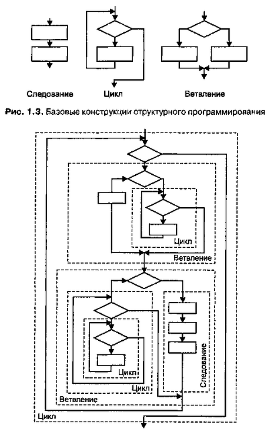

Рис. 4.6. Вложение базовых конструкций

Целью использования базовых конструкций является получение программы простой структуры. Такую программу легко читать (а программы чаще приходится читать, чем писать), отлаживать и при необходимости вносить в нее изменения.

В большинстве языков высокого уровня существует несколько реализаций базовых конструкций; в С# есть четыре вида циклов и два вида ветвлений (на два и на произвольное количество направлений). Они введены для удобства программирования, и в каждом случае надо выбирать наиболее подходящие средства. Главное, о чем нужно помнить даже при написании самых простых программ, - они должны состоять из четкой последовательности блоков строго определенной структуры. «Кто ясно мыслит, тот ясно излагает» - практика давно показала, что программы в стиле «поток сознания» нежизнеспособны, не говоря о том, что они просто некрасивы.

Стр. 88

# Обработка исключительных ситуаций

В языке С# есть операторы, позволяющие обнаруживать и обрабатывать ошибки (исключительные ситуации), возникающие в процессе выполнения программы. Об этом уже упоминалось в разделе «Введение в исключения» (см. с. 46), а сейчас мы рассмотрим механизм обработки исключений более подробно.

Исключительная ситуация, или исключение, - это возникновение аварийного события, которое может порождаться некорректным использованием аппаратуры или неправильной работой программы, например делением на ноль или переполнением. Обычно эти события приводят к завершению программы с системным сообщением об ошибке. С# дает программисту возможность восстановить работоспособность программы и продолжить ее выполнение.

Исключения С# не поддерживают обработку асинхронных событий, таких как ошибки оборудования или прерывания, например нажатие клавиш Ctrl+C. Механизм исключений предназначен только для событий, которые могут произойти в результате работы самой программы и указываются явным образом. Исключения возникают тогда, когда некоторая часть программы не смогла сделать то, что от нее требовалось. При этом другая часть программы может попытаться сделать что-нибудь иное.

Исключения позволяют логически разделить вычислительный процесс на две части - обнаружение аварийной ситуации и ее обработка. Это важно не только для лучшей структуризации программы. Главное то, что функция, обнаружившая ошибку, может не знать, что предпринимать для ее исправления, а использующий эту функцию код может знать, что делать, но не уметь определить место возникновения. Это особенно актуально при использовании библиотечных функций и программ, состоящих из многих модулей.

Другое достоинство исключений состоит в том, что для передачи информации об ошибке в вызывающую функцию не требуется применять возвращаемое значение или параметры, поэтому заголовки функций не разрастаются.

# ПРИМЕЧАНИЕ

В принципе, ничто не мешает рассматривать в качестве исключений не только ошибки, но и нормальные ситуации, возникающие при обработке данных, но это не имеет преимуществ перед другими решениями, не улучшает структуру программы и не делает ее понятнее.

Исключения генерирует либо среда выполнения, либо программист с помощью оператора throw. В табл. 4.1 приведены наиболее часто используемые стандартные исключения, генерируемые средой. Они определены в пространстве имен System, Все они являются потомками класса Exception, а точнее, потомками его потомка SystemException. Исключения обнаруживаются и обрабатываются в операторе try.

Стр. 89

Таблица 4.1. Часто используемые стандартные исключения

- Имя - Описание
- ArithmeticException - Ошибка в арифметических операциях или преобразованиях (является предком DivideBeZeroException и OverFlowException)
- ArrayTypeMismatchException - Попытка сохранения в массиве элемента несовместимого типа
- DivideByZeroException - Попытка деления на ноль
- FormatException - Попытка передать в метод аргумент неверного формата
- Index0utOfRangeException - Индекс массива выходит за границы диапазона
- InvalidCastException - Ошибка преобразования типа
- OutOfMemoryException - Недостаточно памяти для создания нового объекта
- OverFlowException - Переполнение при выполнении арифметических операций
- StackOverFlowException - Переполнение стека

# Оператор try

Оператор try содержит три части:

- контролируемый блок - составной оператор, предваряемый ключевым словом try. В контролируемый блок включаются потенциально опасные операторы программы. Все функции, прямо или косвенно вызываемые из блока, также считаются ему принадлежащими;
- один или несколько обработчиков исключений - блоков catch, в которых описывается, как обрабатываются ошибки различных типов;
- блок завершения finally выполняется независимо от того, возникла ошибка в контролируемом блоке или нет.

Синтаксис оператора try:

```
try блок [ блоки catch ] [ блок finally ]
```

Отсутствовать могут либо блоки catch, либо блок finally, но не оба одновременно. Рассмотрим, каким образом реализуется обработка исключительных ситуаций.

1. Обработка исключения начинается с появления ошибки, Функция или операция, в которой возникла ошибка, генерирует исключение, Как правило, исключение генерируется не непосредственно в блоке try, а в функциях, прямо или косвенно в него вложенных.
2. Выполнение текущего блока прекращается, отыскивается соответствующий обработчик исключения, и ему передается управление.
3. Выполняется блок finally, если он присутствует (этот блок выполняется и в том случае, если ошибка не возникла).
4. Если обработчик не найден, вызывается стандартный обработчик исключения, Его действия зависят от конфигурации среды. Обычно он выводит на экран окно с информацией об исключении и завершает текущий процесс.

Стр. 90

# ПРИМЕЧАНИЕ

Подобные окна не предназначены для пользователей программы, поэтому все исключения, которые могут возпикнуть в программе, должны быть перехвачены и обработаны.

Обработчики исключений должны располагаться непосредственно за блоком try. Они начинаются с ключевого слова catch, за которым в скобках следует тин обрабатываемого исключения. Можно записать один или несколько обработчиков в соответствии с типами обрабатываемых исключений. Блоки catch просматриваются в том порядке, в котором они записаны, пока не будет найден соответствующий типу выброшенного исключения.

Синтаксис обработчиков напоминает определение функции с одним параметром - типом исключения. Существуют три формы записи:

```
catch( тип имя ) { … /* тело обработчика */ }
catch( тип ) {.../* тело обработчика */}
catch {.../* тело обработчика */}
```

Первая форма применяется, когда имя параметра используется в теле обработчика для выполнения каких-либо действий, например вывода информации об исключении.

Вторая форма не предполагает использования информации об исключении, играет роль только его тип.

Третья форма применяется для перехвата всех исключений. Так как обработчики просматриваются в том порядке, в котором они записаны, обработчик третьего типа (он может быть только один) следует помещать после всех остальных.

Пример:

```
try
{
    // Контролируемый блок
}
catch ( OverflowException e )
{
    // Обработка исключений класса OverflowException (переполнение)
}
catch ( DivideByZeroException )
{
    // Обработка исключений класса DivideByZeroException (деление на 0)
}
catch
{
    // Обработка всех остальных исключений
}
```

Стр. 91

Если исключение в контролируемом блоке не возникло, все обработчики пропускаются. В любом случае, произошло исключение или нет, управление передается в блок завершения finally (если он существует), а затем - первому оператору, находящемуся непосредственно за оператором try. В завершающем блоке обычно записываются операторы, которые необходимо выполнить независимо от того, возникло исключение или нет, например, закрытие файлов, с которыми выполнялась работа в контролируемом блоке, или вывод информации. В листинге 4.9 приведена программа, вычисляющая силу тока по заданным напряжению и сопротивлению. Поскольку вероятность неверного набора вещественного числа довольно высока, оператор ввода включен в контролируемый блок.

# ПРИМЕЧАНИЕ

Исключение, связанное с делением на ноль, для вещественных значений возникнуть не может, поэтому не проверяется. При делении на ноль будет выдан результат «бесконечность».

Листинг 4.9. Использование исключений для проверки ввода

```
using System;
namespace ConsoleApplicationl
{
    class Program
    {
        static void Main()
        {
            string buf;
            double u, i, r;
            try
            {
                Console.WriteLine( "Введите напряжение:" );
                u = double.Parse( Console.ReadLine() ):
                Console. WriteLine( "Введите сопротивление:");
                r = double.Parse( Console.ReadLine() );
                i=u/r;
                Console.WriteLine( "Сила тока - "+i;);
            }
```

```
            catch ( FormatException )
            {
                Console WriteLine( "Неверный формат ввода!" );
            }
            catch // общий случай
            {
                Console.WriteLine( "Hеопознанное исключение" );
            }
        }
    }
}
```

Стр. 92

Операторы try могут многократно вкладываться друг в друга, Исключение, которое возникло во внутреннем блоке try и не было перехвачено соответствующим блоком catch, передается на верхний уровень, где продолжается поиск подходящего обработчика. Этот процесс называется распространением исключения.

Распространение исключений предоставляет программисту интересные возможности. Например, если на внутреннем уровне недостаточно информации для того, чтобы провести полную обработку ошибки, можно выполнить частичную обработку и сгенерировать исключение повторно, чтобы оно было обработано на верхнем уровне. Генерация исключения выполняется с помощью оператора throw.

# Оператор throw

До сих пор мы рассматривали исключения, которые генерирует среда выполнения С#, но это может сделать и сам программист. Для генерации исключения используется оператор throw с параметром, определяющим вид исключения. Параметр должен быть объектом, порожденным от стандартного класса System, Exception. Этот объект используется для передачи информации об исключении его обработчику. Оператор throw употребляется либо с параметром, либо без него:

```
throw [ выражение ];
```

Форма без параметра применяется только внутри блока catch для повторной генерации исключения. Тип выражения, стоящего после throw, определяет тип исключения, например:

```
throw new DivideByZeroException();
```

Здесь после слова throw записано выражение, создающее объект стандартного класса «ошибка при делении на 0» с помощью операции new. При генерации исключения выполнение текущего блока прекращается и происходит поиск соответствующего обработчика с передачей ему управления. Обработчик считается найденным, если тип объекта, указанного после throw, либо тот же, что задан в параметре catch, либо является производным от него.

Рассмотрим пример, приведенный в спецификации С#:

```
using System;
class Test
{
    static void F()
    {
        try
        {
            G(); // функция, в которой может произойти исключение
        }
        catch ( Exception e )
        {
            Console.Writeline( "Exception in F: " + e.Message );
            e = new Exception( "F");
            throw; //повторная генерация исключения
        }
    }
    static void G()
    {
        throw new Exception( "G" ); // моделирование исключительной ситуации
    }
    static void Main()
    {
        try
        {
            F();
        }
        catch ( Exception e )
        {
            Console.WriteLine( "Exception in Main: " + e.Message ):
        }
    }
}
```

Стр. 93

В методе F выполняется промежуточная обработка исключения, которая заключается в том, что на консоль выводится поле Message перехваченного объекта е (об элементах класса Exception рассказывается в следующем разделе). После этого исключение генерируется заново. Несмотря на то что в обработчике исключения создается новый объект класса Exception с измененной строкой информации, передаваемой в исключении, выбрасывается не этот объект, а тот, который был перехвачен обработчиком, поэтому результат работы программы следующий:

```
Exception in F: G
Exception in Main: G
```

Заменим оператор throw таким оператором:

```
throw e;
```

В этом случае в обработчике будет выброшено исключение, созданное в предыдущем операторе, и вывод программы изменится:

```
Exception in F: G
Exception in Main: F
```

С обработкой исключений мы еще не раз встретимся в примерах программ, приведенных в следующих главах.

# Класс Exception

Класс Except.ion содержит несколько полезных свойств, с помощью которых можно получить информацию об исключении. Они перечислены в табл. 4.2.

Таблица 4.2. Свойства класса System. Exception

- Свойство - Описание
- Helpiink - URL файла справки с описанием ошибки
- Message - Текстовое описание ошибки. Устанавливается при создании объекта. Свойство доступно только для чтения
- Source - Имя объекта или приложения, которое сгенерировало ошибку
- StackTrace - Последовательность вызовов, которые привели к возникновению ошибки. Свойство доступно только для чтения
- InnerException - Содержит ссылку на исключение, послужившее причиной генерации текущего исключения
- TargetSite - Метод, выбросивший исключение

Стр. 94

# Операторы checked и unchecked

Как уже упоминалось в главе 3, процессом генерации исключений, возникающих при переполнении, можно управлять с помощью ключевых слов checked и unchecked, которые употребляются как операции, если они используются в выражениях, и как операторы, если они предваряют блок, например:

```
a = checked (b + c); // для выражения (проверка включена)
unchecked // для блока операторов (проверка выключена)
{
    a = b + c;
}
```

Проверка не распространяется на функции, вызванные в блоке.

# Рекомендации по программированию

К настоящему моменту вы изучили основные операторы С# и можете писать на этом языке простые программы, используя класс, состоящий из одного метода. Даже на этом уровне важно придерживаться определенных правил, следование которым поможет вам избежать многих распространенных ошибок. Конечно, на все случаи жизни советы дать невозможно, ведь не зря многие считают программирование искусством. С приобретением опыта вы добавите к приведенным далее правилам множество своих, выстраданных в результате долгих бдений над «последней» ошибкой.

# ВНИМАНИЕ

Главная цель, к которой нужно стремиться, - получить поцятную программу как можно более простой структуры. В конечном счете, все технологии программирования направлены на достижение именно этой пели, поскольку только так можно добиться надежности программы и легкости ее модификации. Создание программы надо начинать с определения ее исходных данных и результатов. При этом задумываются не только о смысле каждой величины, но и о том, какое множество значений она может принимать. В соответствии с этим выбираются типы переменных. Следующий шаг - записать на естественном языке (возможно, с применением обобщенных блок-схем), что именно и как должна делать программа. Если вы не можете сформулировать алгоритм по-русски, велика вероятность того, что он плохо продуман (естественно, я не имею в виду, что надо «проговаривать» все на уровне отдельных операторов, например, «изменяя индекс от 0 до 100 с шагом 1…»). Описание алгоритма полезно по нескольким причинам: оно помогает в деталях продумать алгоритм, найти на самой ранней стадии некоторые ошибки, разбить программу на логическую последовательность блоков, а также обеспечить комментарии к программе.

Стр. 95

При кодировании ( Кодированием называют процесс написания текста программы, чтобы отличить его от более общего понятия «программирование», включающего также этапы проектирования и отладки программы.) программы необходимо помнить о принципах структурного программирования: программа должна состоять из четкой последовательности блоков - базовых конструкций, каждая из которых имеет один вход и один выход. Конструкции могут вкладываться, но не пересекаться. Программа должна быть «прозрачна». Если какое-либо действие можно запрограммировать разными способами, то предпочтение должно отдаваться не наиболее компактному и даже не наиболее эффективному, а более понятному. Особенно это важно тогда, когда пишут программу одни, а сопровождают другие, что является широко распространенной практикой. «Непрозрачное» программирование может повлечь за собой огромные издержки, связанные с поиском ошибок при отладке.

Для записи каждого фрагмента алгоритма необходимо использовать наиболее подходящие средства языка. Например, ветвление на насколько направлений по значению целой или строковой переменной эффектнее записать с помощью одного оператора switch, а не нескольких операторов if. Для просмотра массива лучше пользоваться циклом for или foreach. Оператор goto применяют весьма редко, например, в операторе выбора switch или для принудительного выхода из нескольких вложенных циклов, а в большинстве других ситуаций лучше использовать другие средства языка, такие как break или return.

Для организации циклов пользуйтесь наиболее подходящим оператором. Цикл do применяется только в тех случаях, когда тело в любом случае потребуется выполнить хотя бы один раз, например, при проверке ввода. При использовании циклов надо стремиться объединять инициализацию, проверку условия выхода и приращение в одном месте. Рекомендации по выбору наиболее подходящего оператора цикла были приведены на с. 82.

При записи итеративных циклов (в которых для проверки условия выхода используются соотношения переменных, формирующихся в теле цикла), необходимо предусматривать аварийный выход по достижении заранее заданного максимального количества итераций. Это повышает падежность программы. Более короткую ветвь ifлучше поместить сначала, иначе вся структура может не поместиться на экране, что затруднит отладку. Бессмысленно использовать проверку на равенство true или false:

```
bool busy:
...
if ( busy == true ) {...} // плохо! Лучше if ( busy )
if ( busy == false) {...} // плохо! Лучше 1f ( !busy)
```

Следует избегать лишних проверок условий. Например:

```
if ( a < b ) c = 1;
else if ( a > b ) c = 2;
    else if ( a b ) c = 3;
```

Стр. 96

Вместо этих операторов можно написать:

```
if ( a < b ) c = 1 ;
else if ( a >b ) c = 2 ;
else c = 3 ;
```

Или даже так:

```
C = 3;
if ( a < b ) c = 1 ;
if ( a > b ) c = 2 ;
```

Если первая ветвь оператора if обеспечивает передачу управления, использовать ветвь else нет необходимости:

```
if ( i > 0 ) break;
// здесь 1 <= 0
```

В некоторых случаях условная операция лучше условного оператора:

```
if( z==0) i = j;
    else i = k; //  лучше так: i = z== 0 ? j : k ;
```

Читател, рекомендую тебе яростно ставить скобочки. Тогда не возникнет проблем с кодом вааще.

```
if( z==0){i = j;}
    else {i = k;} //  лучше так: i = z== 0 ? j : k ;
```

Кому если интерестно, то где-то в далекой далекой галлактике есть прием...

```
(z==0)
    .Set_If(f_bool:a=>a,f_1:a=>{i = j;},f_2:=>{i = k;})
;
```

Что интерестно - это тоже C#...

Необходимо предусматривать печать сообщений или генерацию исключения в тех точках программы, куда управление при пормальной работе программы передаваться не должно. Именно это сообщение вы с большой вероятностью получите при первом же запуске программы. Например, полезно, если оператор switch имеет ветвь default, реализующую обработку ситуации по умолчанию, если в ней перечислены все возможные значения переключателя. В программе полезно предусматривать реакцию на неверные входные параметры. Это может быть генерация исключения (предночтительно), печать сообщения или формирование признака результата с его последующим анализом. Сообщение об ошибке должно быть информативным и подсказывать пользователю, как ее исправить. Например, при вводе неверного значения в сообщении должен быть указан допустимый диапазон.

Генерируйте исключения в тех случаях, когда в месте возникновения ошибки недостаточно данных, чтобы ее обработать. Заключайте потенциально опасные фрагменты программы в проверяемый блок try и обрабатывайте хотя бы исключение типа Exception, а лучше - все исключения, которые могут в нем возникнуть, по отдельности.

Конечно, все усилия по комментированию программы пропадут втуне, если сама она написана путано, неряшливо и непродуманно. Поэтому после написания программу следует тщательно отредактировать - убрать ненужные фрагменты, сгруппировать описания, оптимизировать проверки условий и циклы, проверить, оптимально ли разбиение на методы, и т. д. С первого раза без помарок хороший текст не напишешь, будь то сочинение, статья или программа, Однако не следует пытаться оптимизировать все, что «попадается под руку», поскольку главный принцип программиста тот же, что и врача: «Не навреди!». Если программа работает недостаточно эффективно, надо в первую очередь подумать о том, какие алгоритмы в нее заложены.

Стр. 97

Подходить к написанию программы нужно таким образом, чтобы ее можно было в любой момент передать другому программисту. Полезно дать почитать свою программу кому-нибудь из друзей или коллег (а еще лучше - врагов или завистников) и в тех местах, которые они не смогут понять без устных комментариев, внести их прямо в текст программы. Комментарии имеют очень важное значение, поскольку программист, как ни странно, чаще читатель, чем писатель. Даже если сопровождающим программистом является автор программы, разбираться через год в плохо документированном тексте - сомнительное удовольствие. Дальнейшие советы касаются комментариев и форматирования текста программы, что является неотъемлемой частью процесса программирования.

Программа, если она используется, живет не один год, потребность в каких-то ее новых свойствах проявляется сразу же после ввода в эксплуатацию, и сопровождение программы занимает гораздо больше времени, чем ее нанисание. Основная часть документации должна находиться в тексте программы. Хорошие комментарии написать почти так же сложно, как и хорошую программу. В С# есть мощные средства документирования программ, речь о которых пойдет в главе 15, но само содержание комментариев никто, кроме вас, задать не сможет.

Комментарии должны представлять собой правильные предложения без сокращений и со знаками препинания (Совсем хорошо, если они при этом не будут содержать орфографических ошибок.) и не должны подтверждать очевидное (комментарии в этой книге не могут служить образцом, поскольку они предназначены для обучения, а не сопровождения). Например, бессмысленны фразы типа «вызов метода f» или «описание переменных». Если комментарий к фрагменту программы занимает несколько строк, разместить его лучше перед фрагментом, чем справа от него, и выровнять по вертикали.

Вложенные блоки должны иметь отступ в 3-5 символов, причем блоки одного уровня вложенности должны быть выровнены по вертикали. Форматируйте текст по столбцам везде, где это возможно, это делает программу гораздо понятнее:

```
string buf = "qwerty";
double ex = 3.1234;
int number = 12;
byte z = 0;
...
if ( done ) Console.WriteLine( "Сумма ряда - " + y );
else Console.Writeline( "Ряд расходится" );
...
if ( x>= 0 ) y = t * x;
else if( x >= 10 ) y = 2 * t;
else y = x;
```

Стр. 98

В последних трех строках показано, что иногда большей ясности можно добиться, если не следовать правилу отступов буквально. Абзацный отступ комментария должен соответствовать отступу комменти- руемого блока:

```
// Комментарий, описывающий,
// что происходит в следующем ниже
// блоке программы,
{ /* Непонятный
    блок
    программы */
}
```

Для разделения методов и других логически законченных фрагментов пользуйтесь пустыми строками или комментарием вида

```
//--------------------
```

Не следует размещать в одной строке много операторов. Как и в русском языке, после знаков препинания должны использоваться пробелы:

```
f=a+b; // плохо! Лучше f = a + b;
```

Помечайте конец длинного составного оператора, например:

```
while ( true )
{
    while ( x < y )
    {
        for ( i = 0; i < 10; ++1 )
        {
            for ( j = 0; j < 10; ++j )
            {
                // две страницы кода
            } // end for ( j = 0; j < 10; ++j )
        } // end for ( i = 0; 1 < 10; ++1 )
    { // end while ( x < y )
}  // end while ( true )
```

Конструкции языка С# в основном способствуют хорошему стилю программирования, тем не менее, и на этом языке легче легкого написать запутанную, ненадежную, некрасивую программу, которую проще переписать запово, чем внести в нее требуемые изменения, Только постоянные тренировки, самоконтроль и стремление к совершенствованию помогут вам освоить хороший стиль, без которого невозможно стать квалифицированным программистом. Вообще говоря, этот не блешущий новизной совет можно отнести практически к любому роду человеческой деятельности. В заключение порекомендую тем, кто предпочитает учиться программированию не только на своих ошибках, очень полезные книги $[$2$]$, $[$6$]$.

Стр. 99

# Глава 5 Классы: основные понятия

Понятие о классах вы получили (А может быть, и не получили.) в разделах «Классы» (см. с. 13) и «Заготовка консольной программы» (см. с. 17). Все программы, приведенные в этой книге ранее, состояли из одного класса с одним-единственным методом Main. Сейчас настало время подробнее изучить состав, правила создания и использования классов. По сути, отныне все, что мы будем рассматривать, так или иначе связано с этим ключевым средством языка.

Класс является типом данных, определяемым пользователем. Он должен представлять собой одну логическую сущность, например, являться моделью реального объекта или процесса. Элементами класса являются данные и функции, предназначенные для их обработки.

Описание класса содержит ключевое слово class, за которым следует его имя, а далее в фигурных скобках - тело класса, то есть список его элементов. Кроме того, для класса можно задать его базовые классы (предки) и ряд необязательных атрибутов и спецификаторов, определяющих различные характеристики класса:

```
[ атрибуты ] [ спецификаторы ] class имя класса [ : предки ]
    тело_класса
```

Как видите, обязательными являются только ключевое слово class, а также имя и тело класса. Имя класса задается программистом по общим правилам С#. Тело класса - это список описаний его элементов, заключенный в фигурные скобки. Список может быть пустым, если класс не содержит ни одного элемента. Таким образом, простейшее описание класса может выглядеть так:

```
class Demo ()
```

# ПРИМЕЧАНИЕ

Необязательные атрибиты задают дополнительную информацию о классе. Поскольку наша ладача пока состоит в том, чтобы освонть основные понятия, мы отложим знакомство с итрибутами до главы 12.

Спецификаторы определяют свойства класса, а также доступность класса для других элементов программы. Возможные значения спецификаторов перечислены в табл. 5.1. Класс можно описывать непосредственно внутри пространства имен или внутри другого класса. В последнем случае класс называется вложенным. В зависимости от места описания класса некоторые из этих спецификаторов могут быть запрещены.

Стр. 100

Таблица 5.1. Спецификаторы класса

| № | Спецификатор | Описание |
| --- | --- | --- |
| 1 | new | Используется для вложенных классов. Задает новое описание класса взамен унаследованного от предка. Применяется в иерархиях объектов, рассматривается в главе 8 (см. с. 175) |
| 2 | public | Доступ не ограничен |
| 3 | protected | Используется для вложенных классов. Доступ только из элементов данного и производных классов |
| 4 | internal | Доступ только из даглой программы (сборки) Понятие сборки было введено в главе 1 на с. 9. |
| 5 | protected internal | Доступ только из данного и производных классов или из данной программы (сборки) |

| № | Спецификатор | Описание |
| --- | --- | --- |
| 6 | private | Используется для вложенных классов. Доступ только из элементов класса, внутри которого описан данный класс |
| 7 | abstract | Абстрактный класс. Применяется в иерархиях объектов, рассматривается в главе 8 (см. с. 181) |
| 8 | sealed | Бесплодный класс. Применяется в иерархиях объектов, рассматривается в главе 8 (см. с. 182) |
| 9 | static | Статический класс. Введен в версию языка 2.0. Рассматривается в разделе «Конструкторы» (см. с. 114) |

Спецификаторы 2-6 называются спецификаторами доступа. Они определяют, откуда можно непосредственно обращаться к данному классу. Спецификаторы доступа могут присутствовать в описании только в вариантах, приведенных в таблице, а также могут комбинироваться с остальными спецификаторами.

В этой главе мы будем изучать классы, которые описываются в пространстве имен непосредственно (то есть не вложенные классы). Для таких классов допускаются только два спецификатора: public и internal. По умолчанию, то есть если ни один спецификатор доступа не указан, подразумевается спецификатор internal.

Класс является обобщенным понятием, определяющим характеристики и поведение некоторого множества конкретных объектов этого класса, называемых экземплярами, или объектами, класса.

Объекты создаются явным или неявным образом, то есть либо программистом, либо системой. Программист создает экземпляр класса с помощью операции new, например:

```
Demo a = new Demo(); // создание экземпляра класса Demo
Demo b = new Demo(); // создание другого экземпляра класса Demo
```

Стр. 101

# ПРИМЕЧАНИЕ

Для каждого объекта при его создании в памяти выделяется отдельная область, в которой хранятся его данные. Кроме того, в классе могут присутствовать статические элементы, которые существуют в единственном экземпляре для всех объектов класса. Часто статические данные называют данными класса, а остальные - данными экземпляра.

Функциональные элементы класса не тиражируются, то есть всегда хранятся в единственном экземпляре. Для работы с данными класса используются методы класса (статические методы), для работы с данными экземпляра - методы экземпляра, или просто методы.

До сих пор мы использовали в программах только один вид функциональных элементов класса - методы. Поля и методы являются основными элементами класса. Кроме того, в классе можно задавать целую гамму других элементов: свойства, события, индексаторы, операции, конструкторы, деструкторы, а также типы (рис. 5.1).

Ниже приведено краткое описание всех элементов класса (см. также рис. 5.1):

- Константы класса хранят неизменяемые значения, связанные с классом.
- Поля содержат данные класса.
- Методы реализуют вычисления или другие действия, выполияемые классом или экземпляром.
- Свойства определяют характеристики класса в совокупности со способами их задания и получения, то есть методами записи и чтения.
- Конструкторы реализуют действия по инициализации экземпляров или класса в целом.
- Деструкторы определяют действия, которые необходимо выполнить до того, как объект будет уничтожен.
- Индексаторы обеспечивают возможность доступа к элементам класса по их порядковому цомеру.
- Операции задают действия с объектами с помощью знаков операций.
- События определяют уведомления, которые может генерировать класс.
- Типы - это типы данных, внутренние по отношению к классу.

Первые пять видов элементов класса мы рассмотрим в этой главе, а остальные - в последующих. Но прежде чем начать изучение, необходимо поговорить о при- сваивании и сравнении объектов.

Стр. 102

- Класс
  - Локальные типы
  - Данные
    - Поля (переменные)
      - Поля экземпляра (Один набор на каждый экземпляр)
      - Статические поля
    - Константы == Статические поля (Один набор на класс)
  - Функции
    - Свойства
    - События
    - Индексаторы
    - Методы
      - Операции
      - Конструкторы
        - Конструкторы экземпляра
        - Статические конструкторы
      - Деструкторы
      - Обычные методы
        - Метод Экземпляра
        - Метод класса

Рис. 5.1. Состав класса

# Присваивание и сравнение объектов

Операция присваивания рассматривалась в разделе «Операции присваивания» (см. с. 57). Механизм выполнения присваивания один и тот же для величин любого типа, как ссылочного, так и значимого, однако результаты различаются. При присваивании значения копируется значение, а при присваивании ссылки - ссылка, поэтому после присваивания одного объекта другому мы получим две ссылки, указывающие на одну и ту же область памяти (рис. 5.2).

Рисунок иллюстрирует ситуацию, когда было создано три объекта, а, b и с, а затем выполнено присваивание b = с. Старое значение b становится недоступным и очищается сборщиком мусора. Из этого следует, что если изменить значение одной величины ссылочного типа, это может отразиться на другой (в данном случае, если изменить объект через ссылку с, объект b также изменит свое значение).

Аналогичная ситуация с операцией проверки на равенство. Величины значимого типа равны, если равны их значения. Величины ссылочного типа равны, если они ссылаются на одни и те же данные (на рисунке объекты b и с равны, но а не равно b даже при равенстве их значений или если они обе равны null).

- Стек - Хип
- Ссылка a -> Значение a
- Ссылка b -> Значение c
- Ссылка с -> Значение c

Объекты

Рис. 5.2. Присваивание объектов

Стр. 103

# Данные: поля и константы

Данные, содержащиеся в классе, могут быть переменными или константами и задаются в соответствии с правилами, рассмотренными в разделе «Переменные» (см. с. 38) и «Именованные константы» (см. с. 41). Переменные, описанные в классе, пазываются полями класса.

При описании элементов класса можно также указывать атрибуты и специфика- торы, задающие различные характеристики элементов. Синтаксис описания элемента данных приведен ниже:

```
[ атрибуты ] [ спецификаторы ] [ const ] тип иня [ = начальное значение ]
```

До атрибутов мы доберемся еще не скоро, в главе 12, а возможные специфика- торы полей и констант перечислены в табл. 5.2. Для констант можно использовать только спецификаторы 1-6.

Таблица 5.2. Спецификаторы полей и констант класса |№|Спецификатор|Описание| |---|---|---| |1|new|Новое описание поля, скрывающее унаследованный элемент класса| |2|public|Доступ к элементу не ограничен| |3|protected|Доступ только из данного и производных классов| |4|internal|Доступ только иа данной сборки| |5|protected internal|Доступ только из данного и производных классов и из данной сборки| |6|private|Доступ только из данного класса| |7|static|Одно поле для всех экземпляров класса| |8|readonly|Поле доступно только для чтения| |9|volatile|Поле может изменяться другим процессом или системой|

Стр. 104

По умолчанию элементы класса считаются закрытыми (private). Для полей класса этот вид доступа является предпочтительным, поскольку поля определяют внутреннее строение класса, которое должно быть скрыто от пользователя. Все методы класса имеют непосредственный доступ к его закрытым полям.

# ВНИМАНИЕ

Поля, описанные со спецификатором static, а также константы существуют в единственном экземпляре для всех объектов класса, поэтому к ним обращаются не через имя экземпляра, а через имя класса. Если класс содержит только статические элементы, экземпляр класса создавать не требуется. Именно этим фактом мы пользовались во всех предыдущих листингах.

Обращение к полю класса выполняется с помощью операции доступа (точка). Справа от точки задается имя поля, слева - имя экземпляра для обычных полей или имя класса для статических. В листинге 5.1 приведены пример простого класса Demo и два способа обращения к его полям.

Листинг 5.1. Класс Demo, содержащий поля и константу

```
using System:
namespace ConsoleApplicationl
{
    class Demo
    {
        public int a = 1; // поле данных
        public const double c = 1.66; // константа
        public static string s = "Demo"; // статическое поле класса
        double y; // закрытое поле данных
    }
    class Class1
    {
        static void Main()
        {
            Demo x = new Demo(); // создание экземпляра класса
            Console.Writeline( x.a ); // х.а - обращение к полю класса
            Console.WriteLine( Demo.c ); // Demo.c - обращение к константе
            Console.WriteLine( Demo.s ); // обращение к статическому полю
         }
     }
 }
```

Стр. 105

Поле у вывести на экран аналогичным образом не удастся: оно является закрытым, то есть недоступно извне (из класса Class1). Поскольку значение этому полю явным образом не присвоено, среда присваивает ему значение ноль.

# ВНИМАНИЕ

Все поля сначала автоматически инициализируются нулем соответствующего типа (например, полям типа int присваивается 0, а ссылкам на объекты - значение nul1). После этого полю присваивается значение, заданное при его явной инициализации. Задание начальных значений для статических полей выполняется при инициализации класса, а обычных - при создании экземпляра.

Поля со спецификатором readonly предназначены только для чтепия. Установить значение такого поля можно либо при его описании, либо в конструкторе (конструкторы рассматриваются далее в этой главе).

# Методы

Метод - это функциональный элемент класса, который реализует вычисления или другие действия, выполняемые классом или экземпляром. Методы определяют поведение класса. Метод представляет собой законченный фрагмент кода, к которому можно обратиться по имени. Он описывается один раз, а вызываться может столько раз, сколько необходимо. Один и тот же метод может обрабатывать различные данные, переданные ему в качестве аргументов. Синтаксис метода:

```
[ атрибуты ] [ спецификаторы ] тип имя метода ( [ параметры ] ) тело метода
```

Рассмотрим основные элементы описания метода. Первая строка представляет собой заголовок метода. Тело метода, задающее действия, выполняемые методом, чаще всего представляет собой блок - последовательность операторов в фигурных скобках. Позже мы увидим, что для методов некоторых типов вместо тела используется просто точка с запятой.

При описании методов можно использовать спецификаторы 1-7 из табл. 5.2, имеющие тот же смысл, что и для полей, а также спецификаторы virtual, sealed. override, abstract и extern, которые будут pacсмотрены мерe необходимости. Чаще всего для методов задается спецификатор доступа publ1c, ведь методы составляют интерфейс класса - то, с чем работает пользователь, поэтому они должны быть доступны.

Стр. 106

Пример простейшего метода:

```
// метод для получения поля у из листинга 5.1
public double Gety()
{
    return y;
}
```

Тип определяет, значение какого типа вычисляется с помощью метода. Часто употребляется термин «метод возвращает значение», поскольку после выполнения метода происходит возврат в то место вызывающей функции, откуда был вызван метод, и передача туда значения выражения, записанного в операторе return (рис. 5.3). Если метод не возвращает никакого значения, в его заголовке задается тип void, а оператор return отсутствует.

- Вызывающая функция
  - Исполняемый программныйй код до
  - Вызов метода ->
    - Вызываемая функция
    - исполняемый программный код
    - return ; ( возвращаемое значение) ->
  - Исполняемый программный код после

Рис. 5.3. Вызов метода

Параметры используются для обмена информацией с методом. Параметр представляет собой локальную переменную, которая при вызове метода принимает значение соответствующего аргумента. Область действия параметра - весь метод. Например, чтобы вычислить значение синуса для вещественной величины х, мы передаем ее в качестве аргумента в метод Sin класса Math, а чтобы вывести значение этой переменной на экран, мы передаем ее в метод WriteLine класса Console:

```
double x = 0.1;
double y = Math.Sin(x);
Console. WriteLine(x);
```

При этом метод Sin возвращает в точку своего вызова вещественное значение си- пуса, которое присваивается переменной у, а метод WriteLine пичего не возвращает.

# ВНИМАНИЕ

Метод, не возвращающий значенне, вызывается отдельным оператором, а метод. возвращающий значение, - в составе выражения в правой части оператора присваивания.

Параметры, описываемые в заголовке метода, определяют множество значений аргументов, которые можно передавать в метод. Список аргументов при вызове как бы накладывается на список параметров, поэтому они должны попарно соответствовать друг другу. Правила соответствия подробно рассматриваются в следующих разделах.

Стр. 107

Для каждого параметра должны задаваться его тип и имя. Например, заголовок метода Sin выглядит следующим образом:

```
public static double Sin( double a );
```

Имя метода вкупе с количеством, типами и спецификаторами его параметров представляет собой сигнатуру метода - то, по чему один метод отличают от других. В классе не должно быть методов с одинаковыми сигнатурами. В листинге 5.2 в класс Demo добавлены методы установки и получения значения поля у (на самом деле для подобных целей используются не методы, а свойства, которые рассматриваются чуть позже). Кроме того, статическое поле s закрыто, то есть определено по умолчанию как private, а для его получения описан метод Gets, являющий собою пример статического метода.

Листинг 5.2. Простейшие методы

```
using System;
namespace ConsoleApplicationl
{
    class Demo
    {
        public int a = 1;
        public const double c = 1.66;
        static string s = "Demo";
        double y;

        // метод получения поля у
        public double Gety(){return y;}

        // метод установки поля у
        public void Sety( double y_ ){y=_y;}

        // метод получения поля s
        public static string Gets() { return s;}
    }
```

```
    class Classl
    {
        static void Main()
        {
            Demo x = new Demo();
            x.Sety(0.12); //вызов метода установки поля у
            Console.writeline( x Gety() ); // вызов метода получения поля у
            Console.Writeline( Demo Gets() ); // вызов метода получения поля s
            // Console.Writeline( Gets() ); // при вызове из др, метода этого объекта
        }
    }
}
```

Стр. 108

Как видите, методы класса имеют непосредственный доступ к его закрытым полям, Метод, описанный со спецификатором static, должен обращаться только к статическим полям класса. Обратите внимание на то, что статический метод вызывается через имя класса, а обычный - через имя экземпляра.

# ПРИМЕЧАНИЕ

При вызове метода из другого метода того же класса имя класса/экземпляра можно не указывать.

# Параметры методов

Рассмотрим более подробно, каким образом метод обменивается информацией с вызвавшим его кодом. При вызове метода выполняются следующие действия:

1. Вычисляются выражения, стоящие на месте аргументов.
2. Выделяется память под параметры метода в соответствии с их типом.
3. Каждому из параметров сопоставляется соответствующий аргумент (аргументы как бы накладываются на параметры и замещают их).
4. Выполняется тело метода.
5. Если метод возвращает значение, оно передается в точку вызова; если метод имеет тип void, управление передается на оператор, следующий после вызова.

При этом проверяется соответствие типов аргументов и параметров и при необходимости выполняется их преобразование. При несоответствии типов выдается диагностическое сообщение. Листинг 5.3 иллюстрирует этот процесс.

Листинг 5.3. Передача параметров методу

```
using System;
namespace ConsoleApplication1
{
    class Class1
    {
        static int Max(int a, int b) // метод выбора максимального значения
        {
            if ( a > b ) return a;
            else return b;
        }
        static void Main()
        {
```

```
            int a = 2 , b = 4;
            int x = Max( a, b ); // вызов метода Мах
            Console.WriteLine( x ); // результат: 4

            short t1 = 3, t2 = 4;
            int y = Max( t1, 12 ); // вызов метода Маx
            Console.Writeline( y); // результат; 4

            1nt z = Max( a + t1, t1 / 2 * b ); // вызов метода Max
            Console.Writeline( z ): // результат: 5
        }
    }
}
```

Стр. 109

В классе описан метод Мах, который выбирает наибольшее из двух переданных ему значений. Параметры описаны как а и b. В методе Main выполняются три вызова Мax. В результате первого вызова методу Мах передаются два аргумента того же типа, что и параметры, во втором вызове - аргументы совместимого типа, в третьем - выражения.

# ВНИМАНИЕ

Главное требование при передаче параметров состоит в том, что аргументы при вызове метода должны записываться в том же порядке, что и параметры в заголовке метода. Правила соответствия типов аргументов и параметров описаны в следующих разделах.

Количество аргументов должно соответствовать количеству параметров. На имена никаких ограничений не накладывается: имена аргументов могут как совпадать, так и не совпадать с именами параметров.

Существуют два способа передачи параметров: по значению и по ссылке. При передаче по значению метод получает копии значений аргументов, и операторы метода работают с этими копиями. Доступа к исходным значениям аргументов у метода нет, а следовательно, нет и возможности их изменить.

При передаче по ссылке (по адресу) метод получает копии адресов аргументов, он осуществляет доступ к ячейкам памяти по этим адресам и может изменять исходные значения аргументов, модифицируя параметры. В С# для обмена данными между вызывающей и вызываемой функциями предусмотрено четыре типа параметров:

- параметры-значения;
- параметры-ссылки - описываются с помощью ключевого слова ref;
- выходные параметры - описываются с помощью ключевого слова out;
- параметры-массивы - описываются с помощью ключевого слова раrams.

Ключевое слово предшествует описанию типа параметра. Если оно опущено, параметр считается параметром-значением. Параметр-массив может быть только один и должен располагаться последним в списке, например:

```
public int Calculate( int a, ref int b, out int c, params int[] d ) …
```

Стр. 110

# Параметры-значения

Параметр-значение описывается в заголовке метода следующим образом:

```
тип имя
```

Пример заголовка метода, имеющего один параметр-значение целого типа:

```
void P( int x )
```

Имя параметра может быть произвольным. Параметр х представляет собой локальную переменную, которая получает свое значение из вызывающей функции при вызове метода. В метод передается копия значения аргумента.

Механизм передачи следующий: из ячейки памяти, в которой хранится переменная, передаваемая в метод, берется ее значение и копируется в специальную область памяти - область параметров. Метод работает с этой копией, следователь- по, доступа к ячейке, где хранится сама переменная, не имеет. По завершении работы метода область параметров освобождается. Таким образом, для парамет- ров-значений используется, как вы догадались, передача по значению. Ясно, что этот способ годится только для величин, которые не должны измениться после выполнения метода, то есть для его исходных данных.

При вызове метода на месте параметра, передаваемого по значению, может находиться выражение, а также, конечно, его частные случаи - переменная или константа. Должно существовать неявное преобразование типа выражения к типу параметра. О неявных преобразованиях рассказывалось в разделе «Преобразования встроенных арифметических типов-значений» (см. с. 45).

Например, пусть в вызывающей функции описаны переменные и им до вызова метода присвоены значения:

```
int x = 1 ;
sbyte c = 1 ;
ushort y = 1 ;
```

Тогда следующие вызовы метода Р, заголовок которого был описан ранее, будут синтаксически правильными:

```
P( x ); P( c ); P( y ); P( 200 ); P( x/4+1);
```

Стр. 111

# Параметры-ссылки

Во многих методах все величины, которые метод должен получить в качестве исходных данных, описываются в списке параметров, а величина, которую вычисляет метод как результат своей работы, возвращается в вызывающий код с помошью оператора return, Очевидно, что если метод должен возвращать более одной величины, такой способ не годится. Еще одна проблема возникает, если в методе требуется изменить значение каких-либо передаваемых в него величин. В этих случаях используются параметрыссылки. Признаком параметра-ссылки является ключевое слово ref перед описанием параметра:

```
ref тип имя
```

Пример заголовка метода, имеющего один параметр-ссылку целого типа:

```
void P( ref int x )
```

При вызове метода в область параметров копируется не значение аргумента, а его адрес, и метод через него имеет доступ к ячейке, в которой хранится аргумент. Таким образом, параметры-ссылки передаются по адресу (чаще употребляется термин «передача по ссылке»). Метод работает непосредственно с переменной из вызывающей функции и, следовательно, может ее изменить, поэтому если в методе требуется изменить значения параметров, они должны передаваться только по ссылке.

# Внимание

Исходные данные передавать в метод по ссылке не рекомендуется, чтобы исключить возможность их непреднамеренного изменения. Проиллюстрируем передачу параметров-значений и параметров-ссылок на примере (листинг 5.4).

Листинг 5.4. Параметры-значения и параметры-ссылки

```
using System;
namespace ConsoleApplicationl
{
    class Class1
    {
        static void P( int a, ref int b )
        {
            a = 44;
            b = 33;
            Console.WriteLine( "внутри метода {0} (1}", a, b );
        }
        static void Main()
        {
            int a = 2, b = 4;
            Console, WriteLine( "до вызова {0} {1}", a, b );
            P( a, ref b );
            Console.WriteLine( "после вызова {0) {1)", a, b );
        }
    }
}
```

Стр. 112

Результаты работы этой программы:

```
до вызова 2 4
внутри метода 44 33
после вызова 2 33
```

Как видите, значение переменной а в функции Маin не изменилось, поскольку переменная передавалась по значению, а значение переменной b изменилось потому, что она была передана по ссылке.

Несколько иная картина получится, если передавать в метод не величины значимых типов, а экземпляры классов, то есть величины ссылочных типов. Как вы помните, переменная-объект на самом деле хранит ссылку на данные, расположенные в динамической памяти, и именно эта ссылка передается в метод либо по адресу, либо по значению. В обоих случаях метод получает в свое распоряжение фактический адрес данных и, следовательно, может их изменить.

# COВET

Для простоты можно считать, что объекты всегда передаются по ссылке.

Разница между передачей объектов по значению и по ссылке состоит в том, что в последнем случае можно изменить саму ссылку, то есть после вызова метода она может указывать на другой объект.

# Выходные параметры

Довольно часто возникает необходимость в методах, которые формируют несколько величин, например, если в методе создаются объекты или инициализи- руются ресурсы. В этом случае становится неудобным ограничение параметров- ссылок: необходимость присваивания значения аргументу до вызова метода. Это ограничение снимает спецификатор out. Параметру, имеющему этот спецификатор, должно быть обязательно присвоено значение внутри метода, компилятор за этим следит. Зато в вызывающем коде можно ограничиться описанием переменной без инициализации. Изменим описание второго параметра в листинге 5.4 так, чтобы он стал выходным (листинг 5.5).

Листинг 5.5. Выходные параметры

```
using System;
namespace ConsoleApplicationl
{
    class Classl
    {
        static void P( int a, out int b )
        {
            a = 44;
            b = 33;
            Console.WriteLine( "внутри метода {0} {1}", a, b );
        }
        static void Main()
        {
            int a = 2, b;
            P( a, out b );
            Console.WriteLine( "после вызова (0) (1)", a, b );
        }
    }
}
```

Стр. 113

При вызове метода перед соответствующим параметром тоже указывается ключевое слово out.

В списке параметров записывайте сначала все входные параметры, затем - все ссылки и выходные параметры. Давайте параметрам имена, по которым можно получить представление об их назначении.

# Ключевое слово this

Каждый объект содержит свой экземпляр полей класса. Методы находятся в памяти в единственном экземпляре и используются всеми объектами совместно. поэтому необходимо обеспечить работу методов нестатических экземпляров с полями именно того объекта, для которого они были вызваны. Для этого в любой нестатический метод автоматически передается скрытый параметр this, в котором хранится ссылка на вызвавший функцию экземпляр.

В явном виде параметр this применяется для того, чтобы возвратить из метода ссылку на вызвавший объект, а также для идентификации поля в случае, если его имя совпадает с именем параметра метода, например:

```
class Demo
{
    double y;
    // метод Т возвращает ссылку на экземпляр
    public Demo T() { return this; }
    // полю у присваивается значение параметра у
    public void Sety( double y ) { this.y = y; }
}
```

# Конструкторы

Конструктор предназначен для инициализации объекта. Он вызывается автоматически при создании объекта класса с помощью операции new. Имя конструктора совпадает с именем класса, Ниже перечислены свойства конструкторов:

- Конструктор не возвращает значение, даже типа void.
- Класс может иметь несколько конструкторов с разными параметрами для разных видов инициализации.
- Если программист не указал ни одного конструктора или какие-то поля не были инициализированы, полям значимых типов присваивается нуль, полям ссылочных типов - значение пu11,
- Конструктор, вызываемый без параметров, называется конструктором по умолчанию.

До сих пор мы задавали начальные значения полей класса при описании класса (см., например, листинг 5.1). Это удобно в том случае, когда для всех экземпляров класса начальные значения некоторого поля одинаковы. Если же при создании объектов требуется присваивать полю разные значения, это следует делать в конструкторе. В листинге 5.6 в класс Demo добавлен конструктор, а поля сделаны закрытыми (ненужные в данный момент элементы опущены). В программе создаются два объекта с различными значениями полей.

Стр. 114

Листинг 5.6. Класс с конструктором

```
using System;
namespace ConsoleApplicationl
{
    class Demo
    {
        // конструктор с параметрами
        public Demo( int a, double y )
        {
            this.a = a;
            this.y = y;
        }
        // метод получения поля у
        public double Gety() { return y; }
        int a;
        double y;
    }
```

```
    class Class1
    {
        static void Main()
        {
            Demo a new Demo( 300, 0.002 ); // вызов конструктора
            Console.WriteLine( a.Gety() ); // результат: 0.002
            Demo b = new Demo( 1, 5.71 ); // вызов конструктора
            Console, WriteLine( b.Gety() ); // результат: 5.71
        }
    }
}
```

Стр. 115

Часто бывает удобно задать в классе несколько конструкторов, чтобы обес печить возможность инициализации объектов разными способами. Следую щий пример несколько «притянут за уши», по тем не менее иллюстрирует этот тезис:

```
class Demo
{
    // конструктор 1
    public Demo( int a )
    {
        this.a=a;
        this.y = 0.002;
    }
    // конструктор 2
    public Demo( double y )
    {
        this.a = 1;
        this.y = y;
    }
    ...
}
...
Demo x = new Demo( 300 ); // вызов конструктора 1
Demo y = new Demo( 5.71 ); // вызов конструктора 2
```

Все конструкторы должны иметь разные сигнатуры. Если один из конструкторов выполняет какие-либо действия, а другой должен делать то же самое плюс еще что-нибудь, удобно вызвать первый конструктор из второго. Для этого используется уже известное вам ключевое слово this в другом контексте, например:

```
class Demo
{
    // конструктор 1
    public Demo( int a ) { this.a = a; }
    // вызов конструктора 1
    public Demo( int a, double y ) : this( a ){this.y = y;}
    ...
}
```

Конструкция, паходящаяся после двоеточия, называется инициализатором, то есть тем кодом, который исполняется до начала выполнения тела конструктора. Как вы помните, все классы в С# имеют общего предка - класс object. Конструктор любого класса, если не указан инициализатор, автоматически вызывает конструктор своего предка. Это можно сделать и явным образом с помощью ключевого слова base, обозпачающего конструктор базового класса.

Стр. 116

Таким образом, первый конструктор из предыдущего примера можно записать и так:

```
// конструктор 1
public Demo( int a ) : base() { this.a = a; }
```

# ПРИМЕЧАНИЕ

Конструктор базового класса вызывается явным образом в тех случаях, когда сму требуется передать параметры.

До сих пор речь шла об «обычных» конструкторах, или конструкторах экземпляра. Существует второй тип конструкторов - статические конструкторы, или конструкторы класса. Конструктор экземпляра инициализирует данные экземпляра, конструктор класса - данные класса. Статический конструктор не имеет параметров, его нельзя вызвать явным образом. Система сама определяет момент, в который требуется его выполнить. Гарантируется только, что это происходит до создания первого экземпляра объекта и до вызова любого статического метода.

Некоторые классы содержат только статические данные, и, следовательно, создавать экземпляры таких объектов не имеет смысла. Чтобы подчеркнуть этот факт, в первой версии C# описывали пустой закрытый (private) конструктор. Это предотвращало попытки создания экземпляров класса. В листинге 5.7 приведен пример класса, который служит для группировки величин. Создавать экземпляры этого класса запрещено.

```
Листинг 5.7. Класс со статическим и закрытым конструкторами (для версий ниже 2.0)

using System;
namespace ConsoleApplicationl
{
    class D
    {
        private D(){} // закрытый конструктор
        // статический конструктор
        static D(){a = 200;}
        static int a;
        static double b = 0,002;
        public static void Print()
        {
            Console.Writeline( "a = " + a );
            Console. WriteLine( "b = " + b );
        }
```

```
        ...
    }
    class Class2
    {
        static void Main()
        {
            D.Print();
            // ошибка: создать экземпляр невозможно
            D d = new D();
        }
    }
}
```

Стр. 117

# ПРИМЕЧАНИЕ

В классе, состоящем только из статических элементов (полей и констант), описывать статический конструктор не обязательно, начальные значения полей удобнее задать при их описании.

В версию 2.0 введена возможность описывать статический класс, то есть класс с модификатором static. Экземпляры такого класса создавать запрещено, и кроме того, от него запрещено наследовать. Все элементы такого класса должны явным образом объявляться с модификатором static (константы и вложенные типы классифицируются как статические элементы автоматически). Конструктор экземпляра для статического класса задавать, естественно, запрещается.

В листинге 5.8 приведен пример статического класса.

Листинг 5.8. Статический класс (начиная с версии 2.0)

```
using System;
namespace ConsoleApplicationl
{
    static class D
    {
        static int a = 200;
        static double b = 0.002;

        public static void Print ()
        {
            Console.WriteLine( "a = " + a);
            Console.WriteLine( "b = " + b);
        }
    }
    class Class1 { static void Main() { D. Print(); } }
}
```

Стр. 118

Листинг 5.9. Класс Monster

```
using System;
namespace ConsoleApplication1
{
    class Monster
    {
        public Monster()
        {
            this.name = "Noname";
            this.health = 100;
            this.ammo = 100;
        }
```

```
        public Monster( string name ) : this() { this.name = name; }
        public Monster( int health, int ammo, string name )
        {
            this.name = name;
            this.health = health;
            this.ammo = ammo;
        }
        public string GetName() { return name; }
        public int GetHealth() { return health; }
        public int GetAmmo() { return ammo; }
        public void Passport()
        {
            Console WriteLine( "Monster (0} \t health = (1) ammo = (2}",
                name, health, ammo );
        }
        string name; // закрытые поля
        int health, ammo;
    }
```

```
    class Class1
    {
        static void Main()
        {
            Monster X = new Monster();
            X.Passport();
            Monster Vasia = new Monster( "Vasia" );
            Vasia.Passport();
            Monster Masha = new Monster( 200, 200. "Masha" );
            Masha.Passport();
        }
    }
}
```

Стр. 119

Результат работы программы:

```
Monster Noname health - 100 ammo - 100
Monster Vasia health = 100 ammo - 100
Monster Masha health = 200 ammo = 200
```

В классе три закрытых поля (name, health и ammo), четыре метода (GetName, GetHealth, GetAmmo и Passport) и три конструктора, позволяющие задать при создании объекта ни одного, один или три параметра.

# Свойства

Свойства служат для организации доступа к полям класса. Как правило, свойство связано с закрытым полем класса и определяет методы его получения и установки. Синтаксис свойства:

```
[ атрибуты ] [ спецификаторы ] тип имя_свойства
{
    [ get код доступа ]
    [ set код доступа ]
}
```

Значения спецификаторов для свойств и методов аналогичны. Чаще всего свойства объявляются как открытые (со спецификатором public), поскольку они входят в интерфейс объекта.

Код достута представляет собой блоки операторов, которые выполняются при получении (get) или установке (set) свойства, Может отсутствовать либо часть get, либо set, но не обе одновременно. Если отсутствует часть set, свойство доступно только для чтения (read-only), если отсутствует часть get, свойство доступно только для записи (write-only). В версии С# 2.0 введена удобная возможность задавать разные уровни доступа для частей get и set. Например, во многих классах возникает потребность обеспечить неограниченный доступ для чтения и ограниченный - для записи.

Спецификаторы доступа для отдельной части должны задавать либо такой же, либо более ограниченный доступ, чем спецификатор доступа для свойства в целом. Например, если свойство описано как public, его части могут иметь любой спецификатор доступа, а если свойство имеет доступ protected internal, его части могут объявляться как internal, protected или private. Синтаксис свойства в версии 2.0 имеет вид

```
[ атрибуты ] [ спецификаторы ] тип имя_свойства
{
    [ [ атрибуты ] [ спецификаторы ] get код доступа ]
    [ [ атрибуты ] [ спецификаторы ] set код доступа ]
}
```

Пример описания свойств:

```
public class Button: Control
{
    private string caption; // закрытое поле, с которым связано свойство
    // свойство
    public string Caption
    {
        // способ получения свойства
        get
        {
            return caption;
        }
        // способ установки свойства
        set
        {
            if (caption != value) { caption = value;}
        }
    }
    ...
}
```

# ПРИМЕЧАНИЕ

Двоеточие между именами Button и Control в заголовке класса Button означает, что класс Button является производным от класса Control.

Метод записи обычно содержит действия по проверке допустимости устанавливаемого значения, метод чтения может содержать, например, поддержку счетчика обращений к полю.

В программе свойство выглядит как поле класса, например:

```
Button ok = new Button();
ok.Caption - "OK"; // вызывается метод установки свойства
string s = ok.Caption; // вызывается метод получения свойства
```

При обращении к свойству автоматически вызываются указанные в нем методы чтения и установки. Синтаксически чтение и запись свойства выглядят почти как методы. Метод get должен содержать оператор return, возвращающий выражение, для типа которого должно существовать неявное преобразование к типу свойства. В методе set используется параметр со стандартным именем value, который содержит устанавливаемое значение. Вообще говоря, свойство может и не связываться с полем. Фактически, оно описывает один или два метода, которые осуществляют некоторые действия над данными того же типа, что и свойство. В отличие от открытых полей, свойства обеспечивают разделение между внутренним состоянием объекта и его интерфейсом и, таким образом, упрощают внесение изменений в класс.

Стр. 121

С помощью свойств можно отложить инициализацию поля до того момента, когда оно фактически потребуется, например:

```
class A
{
    private static Complex0bject x; // закрытое поле
    public static Complex0bject X
    {
    get
    {
        // создание объекта при 1-м обращении
        if (x == null) {             x = new Complex0bject(); }
        return x;
    }
    ...
}
```

Добавим в класс Monster, описанный в листинге 5.9, свойства, позволяющие работать с закрытыми полями этого класса. Свойство Name сделаем доступным только для чтения, поскольку имя объекта задается в конструкторе и его изменение не предусмотрено, в свойствах Health и Ammo введем проверку на положительность устанавливаемой величины. Код класса несколько разрастется, зато упростится его использование.

Вообще говоря, в данном случае логичнее использовать не свойство, а просто поле со спецификатором readonly, Свойство требуется для демонстрации синтаксиса.

Листинг 5.10. Класс Monster со свойствами

```
using System;
namespace ConsoleApplicationl
{
    class Monster
    {
        public Monster()
        {
            this.health = 100;
            this.ammo = 100;
            this.name = "Noname";
        }
```

```
        public Monster( string name ) : this() { this.name = name;}
        public Monster( int health, int ammo, string name )
        {
            this.health = health;
            this.ammo = ammo;
            this.name = name;
        }
        // свойство Health связано с полем health
        public int Health
        {
            get{ return health; }
            set
            {
                1f (value > 0) health = value;
                else health = 0;
            }
        }
```

Стр. 122

```
        // свойство Ammo связано с полем аmmo
        public int Ammo
        {
            get{ return ammo; }
            set
            {
                if (value > 0) ammo = value;
                else ammo = 0;
            }
        }
        // свойство Name связано с полем name
        public string Name { get{ return name; } }
        public void Passport()
        { Console.WriteLine("Monster (0} At health - (1) ammo - (2)". name, health, ammo); }
        string name; // закрытые поля
        int health, ammo;
    }
```

Стр. 123

```
    class Classl
    {
        static void Main()
        {
            Monster Masha = new Monster( 200, 200. "Masha" );
            Masha. Passport():
            --Masha.Health; // использование свойств
            Masha. Ammo += 100; // использование свойств
            Masha. Passport();
        }
    }
}
```

Результат работы программы:

```
Monster Masha health = 200 ammo = 200
Monster Masha health = 199 ammo = 300
```

# Рекомендации по программированию

При создании класса, то есть нового типа данных, следует хорошо продумать его интерфейс - средства работы с классом, доступные использующим его программистам. Интерфейс хорошо спроектированного класса интуитивно ясен, непротиворечив и обозрим. Как правило, он не должен включать поля данных.

Поля предпочтительнее делать закрытыми (private). Это дает возможность впоследствии изменить реализацию класса без изменений в его интерфейсе, а также регулировать доступ к полям класса с помощью набора предоставляемых пользователю свойств и методов. Важно помнить, что поля класса вводятся только для того, чтобы реализовать характеристики класса, представленные в его интерфейсе с помощью свойств и методов.

Не нужно расширять интерфейс класса без необходимости, «на всякий случай», поскольку увеличение количества методов затрудняет понимание класса пользователем1. В идеале интерфейс должен быть полным, то есть предоставлять возможность выполнять любые разумные действия с классом, и одновременно минимально необходимым - беа дублирования и пересечения возможностей методов.

Под пользователем имеется в виду программист, применяющий класс.

Стр. 124

Методы определяют поведение класса. Каждый метод класса должен решать только одну задачу (не надо объединять два коротких независимых фрагмента кода в один метод). Размер метода может варьироваться в широких пределах, все зависит от того, какие функции он выполияет. Желательно, чтобы тело метода помещалось на 1-2 экрана: одинаково сложно разбираться в программе, содержащей несколько необъятных функций, и в россыпи из сотен единиц по несколько строк каждая.

Если метод реализует сложные действия, следует разбить его на последовательность шагов и каждый шаг оформить в виде вспомогательной функции (метода со спецификатором private). Если некоторые действия встречаются в коде хотя бы дважды, их также нужно оформить в виде отдельной функции.

Создание любой функции следует начинать с ее интерфейса, то есть заголовка. Необходимо четко представлять себе, какие параметры функция должна получать и какие результаты формировать. Входные параметры обычно перечисляют в начале списка параметров.

Предпочтительнее, чтобы каждая функция вычисляла ровно один результат, однако это не всегда оправдано. Если величина вычисляется внутри функции и возвращается из нее через список параметров, необходимо использовать перед соответствующим параметром ключевое слово out. Если параметр значимого типа может изменить свою величину внутри функции, его предваряют ключевым словом ref. Величины ссылочного типа всегда передаются по адресу и, следовательно, могут изменить внутри функции свое значение.

Необходимо стремиться к максимальному сокращению области действия каждой переменной, то есть к реализации принципа инкапсуляции. Это упрощает отладку программы, поскольку ограничивает область поиска ошибки. Следовательно, величины, используемые только в функции, следует описывать внутри нее как локальные переменные.

Поля, характеризующие класс в целом, то есть имеющие одно и то же значение для всех экземпляров, следует описывать как статические. Все литералы, связанные с классом (числовые и строковые константы), описываются как поля-кон- станты с именами, отражающими их смысл. При написании кода методов следует руководствоваться правилами, приведенными в аналогичном разделе главы 4 (см. с. 95).

Стр. 125

# Глава 6 Массивы и строки

В этой главе рассматриваются элементы, без которых не обходится практически ни одна программа, - массивы и строки.

# Массивы

До настоящего момента мы использовали в программах простые переменные. При этом каждой области памяти, выделенной для хранения одной величины, соответствует свое имя. Если переменных много, программа, предназначенная для их обработки, получается длинной и однообразной. Поэтому практически в любом языке есть понятие массива - ограниченной совокупности однотипных величин. Элементы массива имеют одно и то же имя, а различаются порядковым номером (индексом). Это позволяет компактно записывать множество операций с помощью циклов.

Массив относится к ссылочным типам данных, то есть располагается в динамической области памяти, поэтому создание массива начинается с выделения памяти под его элементы. Элементами массива могут быть величины как значимых, так и ссылочных типов (в том числе массивы). Массив значимых типов хранит значения, массив ссылочных типов - ссылки на элементы. Всем элементам при создании массива присваиваются значения по умолчанию: нули для значимых типов и nu1l - для ссылочных.

На рис. 6.1 представлен массив, состоящий из пяти элементов любого значимого типа, например int или double, а рис. 6.2 иллюстрирует организацию массива из элементов ссылочного типа.

Стр. 126

Вот, например, как выглядят операторы создания массива из 10 целых чисел и массива из 100 строк:

```
int[] w = new int[10];
string[] z = new string[100];
```

Пять простых переменных

```
a b c d e
```

Массив а из пяти элементов значимого типа (значения в стеке вызова функций)

```
a[0] a[1] a[2] a[3] a[4]
```

Рис. 6.1. Простые переменные и массив из элементов значимого типа

Массив а из пяти элементов ссылочного типа

- a$[$0$]$ -> значение в куче
- a$[$1$]$ -> значение в куче
- a$[$2$]$ -> значение в куче
- a$[$3$]$ -> значение в куче
- a$[$4$]$ -> значение в куче

Рис. 6. 2. Массив из элементов ссылочного типа

В первом операторе описан массив w типа int$[]$. Операция new выделяет память под 10 целых элементов, и они заполняются нулями. Во втором операторе описан массив z типа string$[]$.Операция new выделяет память под 100 ссылок на строки, и эти ссылки заполняются значением nul1. Память под сами строки, составляющие массив, не выделяется - это будет необходимо сделать перед заполнением массива.

Количество элементов в массиве (размерность) не является частью его типа, это количество задается при выделении памяти и не может быть изменено впоследствии. Размерность может задаваться не только константой, но и выражением. Результат вычисления этого выражения должен быть неотрица- тельным, а его тип должен иметь неявное преобразование к int, uint, long или ulong. Пример размерности массива, заданной выражением:

```
short n = … ;
string[] z = new string[n + 1];
```

Элементы массива нумеруются с нуля, поэтому максимальный номер элемента всегда на единицу меньше размерности (например, в описанном выше массиве и элементы имеют индексы от 0 до 9). Для обращения к элементу массива после имени массива указывается номер элемента в квадратных скобках, например:

```
w[4]  z[i]
```

Стр. 127

С элементом массива можно делать все, что допустимо для переменных того же типа. При работе с массивом автоматически выполняется контроль выхода за его границы: если значение индекса выходит за границы массива, генерируется исключение IndexOutOfRangeException. Массивы одного типа можно присваивать друг другу. В более общем виде: можно преобразовать массив, состоящий из элементов некоторого класса а, в массив, состоящий из элементов типа, являющегося базовым для а. При этом происходит присваивание ссылок, а не элементов, как и для любого другого объекта ссылочного типа, папример:

```
int[] a = new int[10];
int[] b = a ; // b и а указывают на один и тот же массив
```

Все массивы в С# имеют общий базовый класс Array, определенный в пространстве имен System. В нем есть песколько полезных методов, упрощающих работу с массивами, например методы получения размерности, сортировки и поиска. Мы рассмотрим эти методы немного позже в разделе «Класс System.Array» (см. с. 133).

# ПРИМЕЧАНИЕ

Массивы, являющиеся полями класса, могут иметь те же спецификаторы, что и поля, представляющие собой простые переменные.

В С# существуют три разновидности массивов: одномерные, прямоугольные и ступенчатые (невыровненные).

# Одномерные массивы

Одномерные массивы используются в программах чаще всего. Варианты описания массива:

```
тип[] имя;
тип[] имя = new тип [ размерность ]:
тип[] имя = { список инициализаторов }:
тип[] имя = new тип [] { список инициализаторов };
тип[] имя = new тип [ размерность ] { список инициализаторов };
```

# ВНИМАНИЕ

При описании массивов квадратные скобки являются элементом синтаксиса, а не указанием на необязательность конструкции.

Примеры описаний (один пример для каждого варианта описания):

```
int[] a; // 1 элементов нет
int[] b = new int[4]; // 2 элементы равны
int[] c = { 61, 2, 5. -9 }; // 3 new подразумевается
int[] d = new int[] { 61. 2. 5. -9 }; // 4 размерность вычисляется
int[] e = new int[4] { 61, 2, 5. -9 }; // 5 избыточное описание
```

Здесь описано пять массивов. Отличие первого оператора от остальных состоит в том, что в нем, фактически, описана только ссылка на массив, а память под элементы массива не выделена. Если список инициализации не задан, размерность может быть не только константой, но и выражением типа, приводимого к целому.

В каждом из остальных массивов по четыре элемента целого типа. Как видно из операторов 3-5, массив при описании можно инициализировать. Если при этом не задана размерность (оператор 4), количество элементов вычисляется по количеству инициализирующих значений. Для полей объектов и локальных переменных можно опускать операцию new, она будет выполнена по умолчанию (оператор 3). Если присутствует и размерность, и список инициализаторов, размерность должна быть константой (оператор 5).

# ПРИМЕЧАНИЕ

Если количество инициализирующих значений не совпадает с размерностью, возникает ошибка компиляции.

В качестве примера рассмотрим программу, которая определяет сумму и количество отрицательных элементов, а также максимальный элемент массива, состоящего из 6 целочисленных элементов (листинг 6.1).

Стр. 128

Листинг 6.1. Работа с одномерным массивом

```
using System;
namespace ConsoleApplicationl
{
    class Classl
    {
        static void Main()
        {
            const int n = 6;
            int[] a = new int[n] { 3. 12, 5. -9, 8. -4};
            Console.WriteLine( "Исходный массив:" ):
            for ( int = 0: i < n; ++i )
                Console.Write( "\t" + a[i] );
            Console. WriteLine();
            long sum = 0; // сумма отрицательных элементов
            int num = 0; // количество отрицательных элементов
```

```
       for ( int i = 0; < n; ++j )
                if ( a[i] < 0 )
                {
                    sum += a[i]:
                    ++num;
                }
            Console.WriteLine( "Сумма отрицательных =" + sum );
            Console.WriteLine( "Кол-во отрицательных =" + num );
            int max = a[0]; // максимальный элемент
            for ( int 1 = 1: i < n: ++1 )
                if ( a[i] > max ) max = a[i];
            Console.WriteLine( "Максимальный элемент = " + max );
        }
    }
}
```

Обратите внимание на то, что для вывода массива требуется организовать цикл.

Стр. 129

# Прямоугольные массивы

Прямоугольный массив имеет более одного измерения. Чаще всего в программах используются двумерные массивы. Варианты описания двумерного массива:

```
тип[,] иня;
тип[,] имя = new тип [ разм_1. разн_2 ];
тип[,] иня = { список инициализаторов };
тип[,] иня = new тип [.] { список инициализаторов };
тип[,] имя = new тип [ разм_1, разм_2 ] { список_инициализаторов };
```

Примеры описаний (один пример для каждого варианта описания):

```
int[,] a; // 1 элементов нет
int[,] b = new int[2, 3]; // 2 элементы равны 0
int[,] c = {{1, 2, 3}, {4, 5, 6}}; // 3 new подразумевается
int[,] с = new int[,] {{1, 2, 3}, {4, 5, 6}}; // 4 размерность вычисляется
int[,] d = new int[2,3] {{1, 2, 3), {4, 5, 6)); // 5 избыточное описание
```

Если список инициализации не задан, размерности могут быть не только константами, но и выражениями типа, приводимого к целому. К элементу двумерного массива обращаются, указывая номера строки и столбца, на пересечении которых он расположен, например:

```
a[1, 4] b[1, j] b[j, 1]
```

# ВНИМАНИЕ

Необходимо помнить, что компилятор воспринимает как номер строки первый индекс, как бы он ни был обозначен в программе.

В качестве примера рассмотрим программу, которая для целочисленной матрицы размером 3 × 4 определяет среднее арифметическое ее элементов и количество положительных элементов в каждой строке (рис. 6.3).

$$ \begin{pmatrix} a_{0;0} &a_{0;1} & ... & a_{0;n-1} &\\ a_{1;0} &a_{1;1} & ... & a_{1;n-1} &\\ ... \\ a_{m-1;0} &a_{m-1;1} & ... & a_{m-1;n-1} &\\ \end{pmatrix}$$

Рис. 6.3. Матрица из m строк и n столбцов

Для нахождения среднего арифметического элементов массива требуется найти их общую сумму, после чего разделить ее на количество элементов. Порядок перебора элементов массива (по строкам или по столбцам) роли не играет. Нахождение количества положительных элементов каждой строки требует просмотра матрицы по строкам. Схема алгоритма приведена на рис. 6.4, программа - в листинге 6.2.

Стр. 130

- 0000 - Начало
- 0001 - Ввести массив
- 0002 - sum = 0
- 0003 - i = 1,m
- 0004 - nPoseI=0
- 0005 - j = 1,n
- 0006 - sum+=a_{i,j}
- 0007 - Если a_{i,j}>0 истина
- 0008 - Условный переход если a_{i,j}>0 истина -> 000B
- 0009 - Если a_{i,j}>0 ложно
- 000A - Условный переход если a_{i,j}>0 ложно -> 000C
- 000B - ++nPosEI
- 000C - Если выражение 1 истина
- 000D - Условный переход если выражени 1 истина -> 0005
- 000E - Если выражение 1 ложно
- 000F - Условный переход если выражение 1 ложно -> 0010
- 0010 - Вывод nPosEI
- 0011 - Если выражение 2 истина
- 0012 - Условный переход если выражени 2 истина -> 0003
- 0013 - Если выражение 2 ложно
- 0014 - Условный переход если выражение 2 ложно -> 0015
- 0015 - Вывод sum/m/n
- 0016 - Оператор конца программы

Рис. 6.4. Структурная схема алгоритма для листинга 6.2

Ну ребят, вот была блок схема. Там многие ячейки просто пустые. Это неприлично.

Листинг 6.2. Работа с двумерным массивом

```
using System;
namespace ConsoleApplication1
{
    class Class1
    {
        static void Main()
        {
            const int m = 3, n = 4;
            int[,] a = new int[m, n]
                {
                    {2,-2, 8, 9 },
                    {4,-5, 6,-2 },
                    {7, 0, 1, 1 }
                }
            ;
```

```
            Console,WriteLine( "Исходный массив:" );
            for ( int 1 = 0; 1 < m; ++i )
            {
                for ( int j= 0; j < n; ++j )
                    Console.Write( "\t" + a[i, j] );
                Console. WriteLine();
            }
            double sum = 0;
            int nPosEl;
```

```
            for ( int i = 0: i < m: ++j )
            {
                nPosE1 = 0;
                for ( int j = 0; j < n; ++j )
                {
                    sum += a[i, j];
                    if ( a[i, j] > 0 ) ++nPosEl;
                }
                Console.WriteLine( "В строке {0} {1} положит-х элементов". i, nPosE1 ):
            }
            Console.WriteLine( "Среднее арифметическое всех элементов: " + sum / m / n );
        }
    }
}
```

Стр. 131

# ПРИМЕЧАНИЕ

Для суммирования элементов описана переменная Sum вещественного типа. Если описать ее как целую, при делении на количество элементов будет отброшена дробная часть.

Обратите внимание на то, что переменная sum обнуляется перед циклом просмотра всей матрицы, а количество положительных элементов - перед циклом просмотра очередной строки, поскольку для каждой строки его вычисление на- чинается заново.

# Ступенчатые массивы

Стр. 132

Комментарий от читателей. Тут картинка... Переверстывать ее я не буду. В литературе есть многомерный массив. Реализуется он несколькими способами.

Первый способ - одномерный сылочный массив, который логически программистом размечается как двумерный. То есть $$a[1;i;n][1;j;m]=a[1;i+j*n;n*m]$$

Второй способ - одномерный массив ссылочного типа данных массив. То есть в каждой ячейке массива другой массив.

Третий способ - ассемблерный. Первый элемент массива - колличество элементов массива. Размечается на уровне логики работы программистом. Или еще вариант. Есть символ конца объекта. В винде это символ перехода на новую строку (char)(int)10+(char)(int)13. В линухе - символ конца строки или объекта 0000h (полный ноль). В линухе и в MSDOS - таким символом вполне может оказаться символ доллара. В стеке вызова функций, в котором размечается область данных функции, есть специальный символ началаа области данных. Это ссылка ячейки оперативной памяти самой на себя. Знания не бог весть какие, но о них умалчивать считаю бесчестным.

Описание ступенчатого массива:

```
тип[][] имя;
```

Под каждый из массивов, составляющих ступенчатый массив, память требуется выделять явным образом, например:

```
int[][] a = new int[3][]; // выделение памяти под ссылки на три строки
a[0] = new int[5]; // выделение памяти под 0-ю строку (5 элементов)
a[1] = int[3]; // выделение памяти под 1-ю строку (3 элемента)
a[2] = int[4]; // выделение памяти под 2-ю строку (4 элемента)
```

Здесь а$[$0$]$, а$[$1$]$ и а$[$2$]$ - это отдельные массивы, к которым можно обращаться по имени (пример приведен в следующем разделе). Другой способ выделения памяти:

```
int[][] a = { new int[5], new int[3], new int[4] };
```

К элементу ступенчатого массива обращаются, указывая каждую размерность в своих квадратных скобках, например:

```
a[1][2] a[i][j] a[j][i]
```

В остальном использование ступенчатых массивов не отличается от использования прямоугольных. Невыровненные массивы удобно применять, например, для работы с треугольными матрицами большого объема.

Стр. 133

# Класс System.Array

Ранее уже говорилось, что все массивы в С# построены на основе базового класса Array, который содержит полезные для программиста свойства и методы, часть из которых перечислены в табл. 6.1.

Таблица 6.1. Основные элементы класса Array

| Элемент | Вид | Описание |
| --- | --- | --- |
| Length | Свойство | Количество элементов массива (по всем размерностям) |
| Rank | Свойство | Количество размерностей массива |
| BinarySearch | Статический метод | Двоичный поиск в отсортированном массиве |
| Clear | Статический метод | Присваивание элементам массива значений по умолчанию |
| Сору | Статический метод | Копирование заданного диапазона элементов одного массива в другой массив |
| CоруТo | Метод | Копирование всех элементов текущего одномерного массива в другой одномерный массив |
| GetValue | Метод | Получение значения элемента массива |
| IndexOf | Статический метод | Поиск первого вхождения элемента в одномерный массив |
| LastIndexOf | Статический метод | Поиск последнего вхождения элемента в одномерный массив |
| Reverse | Статический метод | Изменение порядка следования элементов на обратный |
| SetValue | Метод | Установка значения элемента массива |
| Sort | Статический метод | Упорядочивание элементов одномерного массива |

Свойство Length позволяет реализовывать алгоритмы, которые будут работать с массивами различной длины или, например, со ступенчатым массивом. Использование этого свойства вместо явного задания размерности исключает возможность выхода индекса за границы массива. В листинге 6.3 продемонстрировано применение элементов класса Array при работе с одномерным массивом.

Листинг 6.3. Использование методов класса Array с одномерным массивом

```
using System;
namespace ConsoleApplicationl
{
    class Class1
    {
        static void Main()
        {
            int[] a = {24, 50, 18, 3, 16, -7, 9, -1 };
            PrintArray( "Исходный массив:", a );
            Console.WriteLine( Array.IndexOf( a, 18 ) );
            Array, Sort(a);
            PrintArray( "Упорядоченный массив:", a );
            Console.WriteLine( Array,BinarySearch( a, 18) );
        }
        public static void PrintArray( string header, int[] a )
        {
            Console,Writeline( header );
            for ( int 1 = 0; 1 < a.Length; ++1 )
                Console.Write( "\t" + a[i] );
                Console. WriteLine();
        }
    }
}
```

Стр. 134

Методы Sort, IndexOf и BinarySearch являются статическими, поэтому к ним обращаются через имя класса, а не экземпляра, и передают в них имя массива. Двоичный поиск можно применять только для упорядоченных массивов. Он выполняется гораздо быстрее, чем линейный поиск, реализованный в методе Index0f. В листинге поиск элемента, имеющего значение 18, выполняется обоими этими способами.

# ПРИМЕЧАНИЕ

Рассмотренные методы имеют по несколько версий (в этом случае употребляется термин «перегруженные методы»), что позволяет выполнять поиск, сортировку и копирование как в массиве целиком, как и в его указанном диапазоне.

В классе Class1 описан вспомогательный статический метод PrintArray, предназначенный для вывода массива на экран. В него передаются два параметра: строка заголовка header и массив. Количество элементов массива определяется внутри метода с помощью свойства Length. Таким образом, этот метод можно использовать для вывода любого целочисленного одномерного массива. Результат работы программы:

```
Исходный массив:
    24 50 18 3 16 -7 9 -1 2
Упорядоченный массив:
    -7 -1 3 9 16 18 24 50 5
```

Для того чтобы применять метод PrintArray к массивам, состоящим из элементов другого типа, можно описать его второй параметр как Array, Правда, при этом значение элемента массива придется получать с помощью метода GetValue, поскольку доступ по индексу для класса Array не предусмотрен.

Обобщенный метод вывода массива выглядит так:

```
public static void PrintArray( string header, Array a )
{
    Console.WriteLine( header );
    for ( int i = 0; 1 < a.Length; ++1 )
        Console.Write( "\t" + a.GetValue(1) );
    Console. WriteLine();
}
```

В листинге 6.4 продемонстрировано применение элементов класса Аггаy при работе со ступенчатым массивом.

Стр. 135

Листинг 6.4. Использование методов класса Array со ступенчатым массивом

```
using System;
namespace ConsoleApplicationl
{
    class Class1
    {
        static void Main()
        {
            int[][] a = new int[3][]:
            a[0] = new int [5] { 24, 50, 18, 3, 16 };
            a[1] = new int [3] { 7, 9, -1 };
            a[2] = new int [4] { 6, 15, 3, 1 };
            Console.WriteLine( "Исходный массив:" );
            for ( int i = 0; i < a.Length: ++i )
            {
                for ( int j = 0: j < a[i].Length; ++j )
                    Console.Write( "\t" + a[i][j] );
                Console.WriteLine();
            }
            Console.WriteLine( Array.Index0f( a[0], 18 ) );
        }
    }
}
```

Обратите внимание на то, как внутри цикла по строкам определяется длина каждого массива. Результат работы программы:

```
Исходный массив:
24 50 18 3 16
7 9 -1
6 15 3 1

2
```

# Оператор foreach

Оператор foreach применяется для перебора элементов в специальным образом организованной группе данных, Массив является именно такой группой. Удобство этого вида цикла заключается в том, что нам не требуется определять количество элементов в группе и выполнять их перебор по индексу: мы просто указываем на пеобходимость перебрать все элементы группы. Синтаксис оператора:

```
foreach ( тип имя in выражение ) тело_цикла
```

Имя задает локальную по отношению к циклу переменную, которая будет по очереди принимать все значения из массива пыражение (в качестве выражения чаще всего применяется имя массина или другой групны данных). В простом или составном операторе, представляющем собой тело цикла, выполияются действия с переменной цикла, Тип переменной должен соответствовать типу элемента массива. Например, пусть задан массив:

```
int[] a = { 24, 50, 18, 3, 16, -7, 9, -1 };
```

Вывод этого массива на экрап с помощью оператора foreach выглядит следующим образом:

```
foreach ( int x in a ) Console.WriteLine( x );
```

Стр. 136

Этот оператор выполняется так: на каждом проходе цикла очередной элемент массива присваивается переменной х и с ней производятся действия, записанные в теле цикла. Ступенчатый массив из листинга 6.4 вывести на экран с помощью оператора foreach немного сложнее, чем одномерный, но все же проще, чем с помощью цикла for:

```
foreach ( int[] x in a )
{
    foreach ( int y in x )
        Console.Write( "\t" + y );
    Console. WriteLine();
}
```

В листинге 6.5 решается та же задача, что и в листинге 6.1, но с использованием цикла foreach. Обратите внимание на то, насколько понятнее стала программа.

Листинг 6.5. Работа с одномерным массивом с использованием цикла foreach

```
using System;
namespace ConsoleApplication1
{
    class Class1
    {
        static void Main()
        {
            int[] a = ( 3, 12, 5, -9, 8, -4};
            Console.WriteLine( "Исходный массив:" );
            foreach ( int elem in a )
                Console.Write( "\t" + elem );
            Console.WriteLine();
            long sum = 0; // сумма отрицательных элементов
            int num 0; // количество отрицательных элементов
```

```
        foreach ( int elem in a )
                if ( elem < 0 )
                {
                    sum += elem;
                    ++num;
                }
            Console.Writeline( "sum = " + summ);
            Console.Writeline( "num = " + num );

            int max = a[0]; // максимальный элемент
            foreach ( int elem in a )
                if ( elem > max ) max = elem;
            Console.Writeline( "max =" + max );
        }
    }
}
```

Стр. 137

А вот как можно переписать метод вывода массива из листинга 6.3:

```
public static void PrintArray( string header, Array a )
{
    Console.Writeline( header );
    foreach ( object x in a )
        Console.Write( "\t" + x );
    Console, Writeline();
}
```

Такая запись становится возможной потому, что любой объект может быть неявно преобразован к типу его базового класса, а тип object, как вы помните, является корневым классом всей иерархии. Когда вы продвипетесь в изучении С# до раздела «Виртуальные методы» (см. с. 178), вы поймете механизм выполнения этого кода, а пока можете просто им пользоваться.

# ВНИМАНИЕ

Ограничением оператора foreach является то, что с его помощью можно только просматривать значения в группе данных, но не изменять их.

Стр. 138

# Массивы объектов

При создании массива, состоящего из элементов ссылочного типа, память выделяется только под ссылки на элементы, а сами элементы необходимо разместить в хине явным образом. В качестве примера создадим массив из объектов некото- poro класса Monster:

```
using System;
namespace ConsoleApplicationl
{
    class Monster {...}
    class Class1
    {
        static void Main()
        {
            Random rnd = new Random();
            const int n = 5;
            Monster[] stado = new Monster[n]; // 1
            for ( int 1 0; 1 < n; ++1 ) // 2
            {
                stado[1] = new Monster(
                    rnd.Next( 1, 100 )
                    , rnd.Next( 1, 200 )
                    "Crazy" + i.ToString()
                );
            }
            foreach ( Monster x in stado ) x.Passport(); // 3
        }
    }
}
```

Результат работы программы:

```
Monster Crazy0 health = 18 anmo = 94
Monster Crazyl health = 85 ammo = 75
Monster Crazy2 health = 13 ammo = 6
Monster Crazy3 health = 51 ammo = 104
Monster Crazy4 health = 68 ammo = 114
```

В программе для получения случайных значений использован стандартный класс Random, который описан далее в этой главе (см. с. 148). В операторе 1 выделяется пять ячеек памяти под ссылки на экземпляры класса Monster (из листинга 5.9), и эти ссылки заполняются значением nu11. В цикле 2 создаются пять объектов: операция new выделяет память в хипе необходимого для хранения полей объекта объема, а конструктор объекта заносит в эти поля соответствующие значения (выполняется версия конструктора с тремя параметрами). Цикл 3 демонстрирует удобство применения оператора foreach для работы с массивом.

Стр. 139

# Символы и строки

Обработка текстовой информации является, вероятно, одной из самых распространенных задач в современном программировании, и С# предоставляет для ее решения широкий набор средств: отдельные символы, массивы символов, изменяемые и неизменяемые строки и регулярные выражения.

# Символы

Символьный тип char предназначен для хранения символов в кодировке Unicode. Способы представления символов рассматривались в разделе «Литералы» (см. с. 26). Символьный тип относится к встроенным тинам данных С# и соответствует стандартному классу Char библиотеки .NET из пространства имен System. В этом классе определены статические методы, позволяющие задать вид и категорию символа, а также преобразовать символ в верхний или нижний регистр и в число. Основные методы приведены в табл. 6.2.

Таблица 6.2. Основные методы класса System.Char

- Метод - Описание
- GetNumericValue - Возвращает числовое значение символа, если он является цифрой, и - 1 в противном случас
- GetUnicodeCategory - Возвращает категорию Unicode-символа!
- IsControl - Возвращает true, если символ является управляющим
- IsDigit - Возвращает true, если символ является десятичной цифрой
- IsLetter - Возвращает true, если символ является буквой
- IsLetterOrDigit - Возвращает true, если символ является буквой или цифрой
- IsLower - Возвращает true, если символ задан в нижнем регистре
- IsNumber - Возвращает true, если символ является числом (десятичным или шестнадцатеричным)
- IsPunctuation - Возвращает true, если символ является знаком препинания
- IsSeparator - Возвращает true, если символ является разделителем
- IsUpper - Возвращает true, если символ записан в верхнем регистре
- IsWhiteSpace - Возвращает true, если символ является пробельным (пробел, перевод строки и возврат каретки)
- Parse - Преобразует строку в символ (строка должна состоять из одного символа)
- ToLower - Преобразует символ в нижний регистр
- ToUpper - Преобразует символ в верхний регистр
- MaxValue, MinValue - Возвращают символы с максимальным и минимальным кодами (эти символы не имеют видимого представления)

Все Unicode-симполы разделены на категорни, например, десятичные цифры (Dec mal- DigitNumber), римские цифры (LetterNumber), разделители строк (LineSeparator), буквы в пиж- нем регистре (Lowercaseletter) и т. д.

Стр. 140

В листинге 6.6 продемонстрировано использование этих методов.

Листинг 6.6. Использование методов класса System.Char

```
using System;
namespace ConsoleApplication1
{
    class Class1
    {
        static void Main()
        {
            try
            {
                char b = 'B', c '\x63', d = '\u0032'; // 1
                Console.WriteLine( "{0} {1} {2}", b, c, d );
                Console.Writeline( "{0} {2},
                    char.ToLower(b), char.ToUpper(c), char.GetNumericValue(d)
                );
```

```
                char a;
                do // 2
                {
                    Console.Write( "Введите символ: " );
                    a = char.Parse( Console.ReadLine() );
                    Console.WriteLine( "Введен символ {0}, его код - (1}", a, (int)a );
                    if (char. IsLetter(a)) Console. WriteLine("Буква");
                    if (char, IsUpper(a)) Console.WriteLine("Bерхний per.");
                    if (char. IsLower(a)) Console.WriteLine("Нижний per.");
                    if (char. IsControl(a)) Console.WriteLine("Управляющий");
                    if (char. IsNumber(a)) Console.WriteLine("Число");
                    if (char. IsPunctuation(a)) Console.WriteLine("Разделитель");
                } while (a != q');
            }
```

```
            catch
            {
                Console.WriteLine( "Возникло исключение" );
                return:
            }
        }
    }
}
```

В операторе 1 описаны три символьных переменных. Они инициализируются символьными литералами в различных формах представления. Далее выполняются вывод и преобразование символов. В цикле 2 анализируется вводимый с клавиатуры символ. Можно вводить и управляющие символы, используя сочетание клавиши Ctrl с латинскими буквами. При вводе использован метод Parse, преобразующий строку, которая должна содержать единственный символ, в символ типа char. Поскольку вводится строка, ввод каждого символа следует завершать нажатием клавиши Enter. Цикл выполняется, пока пользователь не введет символ q.

Вывод символа сопровождается его кодом в десятичном виде1. Для вывода кода используется явное преобразование к целому типу. Явное преобразование из символов в строки и обратно в С# не существует, неявным же образом любой объект, в том числе и символ, может быть преобразован в строку2, например:

```
string s = 'к' + 'o' + 'T'; // результат - строка "кот"
```

При вводе и преобразовании могут возникать исключительные ситуации, например, если пользователь введет пустую строку. Для «мягкого» завершения программы предусмотрена обработка исключений. Обратите внимание на коды русских букв: как далеко от латинских они оказались в кодировке Unicode! Об этом рассказывалось в разделе «Простейший ввод-вывод» (см. с. 59).

Стр. 141

# Массивы символов

Массив символов, как и массив любого иного типа, построен на основе базового класса Апray, некоторые свойства и методы которого были перечислены в табл. 6.1. Применение этих методов позволяет эффективно решать некоторые задачи. Простой пример приведен в листинге 6.7.

Листинг 6.7. Работа с массивом символов

```
using System;
namespace ConsoleApplicationl
{
    class Classl
    {
        static void Main()
        {
            char[] a = { 'm', 'a', 's', 's', 'i', 'v'}; // 1
            char[] b = "a роза упала на лапу азора".ToCharArray(); // 2
            PrintArray( "Исходный массив а:", a );
            int pos = Array. IndexOf( a. 'm' ):
            a[pos] = 'M';
            PrintArray( "Измененный массив а:", a );
            PrintArray( "Исходный массив b:". b );
            Array.Reverse( b ):
            PrintArray( "Измененный массив b:", b );
        }
```

```
        public static void PrintArray( string header. Array a )
        {
            Console.WriteLine( header );
            foreach ( object x in a )
                Console.Write( x );
            Console.WriteLine( "\n" );
        }
    }
}
```

Результат работы программы:

```
Исходный массив а:
    massiv
Измененный массив а:
    Massiv
Исходный массив b:
    а роза упала на лапу азора
Измененный массив b:
    ароза упал ан алапу азор а
```

Символьный массив можно инициализировать, либо неносредственно задавая его элементы (оператор 1), либо применяя метод ToCharArray класса string, который разбивает исходную строку на отдельные символы (оператор 2).

Стр. 142

# Строки типа string

Тип string, предназначенный для работы со строками символов в кодировке Unicode, является встроенным типом C#. Ему соответствует базовый класс System.String библиотеки .NET. Создать строку можно несколькими способами:

```
string s; // инициализация отложена
string t = "qqq"; // инициализация строковым литералом
string u = new string( 20); // конструктор создает строку из 20 пробелов
char[] a = {'0', '0', '0'}; // массив для инициализации строки
string v = new string( a ); // создание из массива символов
```

Для строк определены следующие операции:

- присваивание (=);
- проверка на равенство (==);
- проверка на неравенство (!=);
- обращение по индексу ([]);
- сцепление (конкатенация) строк (+).

Несмотря на то что строки являются ссылочным типом данных, на равенство и неравенство проверяются не ссылки, а значения строк. Строки равны, если имеют одинаковое количество символов и совпадают посимвольно. Обращаться к отдельному элементу строки по индексу можно только для получения значения, но не для его изменения. Это связано с тем, что строки типа string относятся к так называемым неизменяемым типом данных'. Методы, изменяющие содержимое строки, на самом деле создают новую копию строки. Неиспользуемые «старые» копии автоматически удаляются сборщиком мусора. В класcе System. String предусмотрено множество методов, полей и свойств, позволяющих выполнять со строками практически любые действия. Основные элементы класса приведены в табл. 6.3.

Наследовать от этого класса также запрещается.

Таблица 6.3. Основные элементы класса System.String

| Название | Вид | Описание |
| --- | --- | --- |
| Compare | Статический метод | Сравнение двух строк в лексикографическом (алфавитном) порядке. Разные реализации метода позволяют сравнивать строки и подстроки с учетом и без учета регистра и особенностей национального представлени… |
| CompareOrdinal | Статический метод | Сравиение двух строк по кодам символов. Разные реализации метода позволяют сравнивать строки и подстроки |
| CompareTo | Метод | Сравнение текущего экземпляра строки с другой строкой |

Стр. 143

| Название | Вид | Описание |
| --- | --- | --- |
| Concat | Статический метод | Конкатенация строк. Метод допускает сцеплени произвольного числа строк |
| Copy | Статический метод | Создание копии строки |
| Empty | Статическое поле | Пустая строка (только для чтения) |
| Format | Статический метод | Форматирование в соответствии с заданными спецификаторами формата (см. далее) |
| IndexOf, IndexOfAny, LastIndexOf, LastIndexOfAny | Методы | Определение индексов первого и последнего вхождения заданной подстроки или любого символа из заданного набора |
| Insert | Метод | Вставка подстроки в заданную позицию |

| Название | Вид | Описание |
| --- | --- | --- |
| Intern, IsInterned | Статические методы | Возвращает ссылку на строку, если такаяуже существует. Если строки нет, Intern добавляет строку во внутренний пул, IsInterned возвращает null |
| Join | Статический метод | Слияние массива строк в единую строку. Между элементами массива вставляются разделители (см. далее) |
| Length | Свойство | Длина строки (количество символов) |
| PadLeft, PadRight | Методы | Выравнивание строки по левому или правому краю путем вставки нужного числа пробелов в начале или в конце строки |
| Remove | Метод | Удаление подстроки из заданной позиции |
| Replace | Метод | Замена всех вхождений заданной подстроки или символа новыми подстрокой или символом |

| Название | Вид | Описание |
| --- | --- | --- |
| Split | Метод | Разделяет строку на элементы, используя заданные разделители. Результаты помещаются в массив строк |
| Startswith, Endswith | Методы | Возвращает true или false в зависимости от того, начинается или заканчивается строка заданной подстрокой |
| Substring | Метод | Выделение подстроки, начиная с заданной позиции |
| ToCharArray | Метод | Преобразование строки в массив символов |
| ToLower, ToUpper | Методы | Преобразование символов строки к нижнему или верхнему регистру |
| Trim, TrimStart, TrimEnd | Методы | Удаление пробелов в начале и конце строки или только с одного ее кония (обратные по отношению к методам Padleft и PadRight действия) |

Стр. 144

Пример применения методов приведен в листинге 6.8.

Листинг 6.8. Работа со строками типа string

```
using System;
namespace ConsoleApplicationl
{
    class Class1
    {
        static void Main()
        {
            string s = "прекрасная королева Изольда" :
            Console.WriteLine( s );
            // 1
            string sub = s.Substring( 3 ).Remove( 12, 2 );
            Console.WriteLine( sub );
```

```
            // 2
            string[] mas = s.Split(' ');
            string joined = string.Join( "! ", mas );
            Console. WriteLine( joined );
            // 3
            Console.WriteLine( "Введите строку" );
            string x = Console.ReadLine();
            Console.WriteLine( "Вы ввели строку " + x );

            double a = 12.234;
            int b = 29:
            Console.WriteLine( " a = {0,6:C} b = {1,2:X}". a, b ); // 4
            Console.WriteLine( " a = (0.6:0.##} b = (1,5:0.# ' руб.'}",a, b ); // 5
            Console.WriteLine( " a = {0:F3} b = {1:D3}", a, b,); // 6
        }
    }
}
```

Результат работы программы:

[output not shown]

В операторе 1 выполняются два последовательных вызова методов: метод Substring возвращает подстроку строки s, которая содержит символы исходной строки, начиная с третьего. Для этой подстроки вызывается метод Remove, удаляющий из нее два символа, начиная с 12-го. Результат работы метода присваивается переменной sub. Аргументом метода Split (оператор 2) является разделитель, в данном случае символ пробела. Метод разделяет строку на отдельные слова, которые запосятся в массив строк mas. Статический метод Join (он вызывается через имя класса) об единяет элементы массива mas в одну строку, вставляя между каждой парой слов строку "! ". Оператор 3 напоминает вам о том, как вводить строки с клавиатуры В операторах 4-6 используется форматирование строк, более подробно описанное в следующем разделе.

Стр. 145

# Форматирование строк

В операторе 4 из листинга 6.8 неявно применяется метод Format, который заменяет все вхождения параметров в фигурных скобках значениями соответствующих переменных из списка вывода, После номера параметра можно задать минимальную ширину поля вывода, а также указать спецификатор формата, который определяет форму представления выводимого значения. В общем виде параметр задается следующим образом:

```
{n [.m[: спецификатор_формата[число]]}
```

Здесь п - номер параметра. Параметры нумеруются с нуля, нулевой параметр заменяется значением первой переменной из списка вывода, первый параметр - второй переменной и т. д. Параметр определяет минимальную ширину поля, которое отводится под выводимое значение. Если выводимому числу достаточно меньшего количества позиций, неиспользуемые позиции заполняются пробелами. Если числу требуется больше позиций, параметр игнорируется. Спецификатор формата, как явствует из его названия, определяет формат вывода значения, Например, спецификатор С (Currency) означает, что параметр должен форматироваться как валюта с учетом национальных особенностей представления. а спецификатор X (Hexadecimal) задает шестнадцатеричную форму представления выводимого значения. После некоторых спецификаторов можно задать количество позиций, отводимых под дробную часть выводимого значения (см. оператор 6).

# ПРИМЕЧАНИЕ

До настоящего момента мы пользовались сокращенной записью, задавая только номера параметров, Список спецификаторов формата приведен в приложении. В операторе 5 из листинга 6.8 используются пользовательские шаблоны форматирования. Если приглядеться, в них пет ничего сложного: после двоеточия задается вид выводимого значения посимвольно, причем на месте каждого символа может стоять либо #, либо 0. Если указан знак #, на этом месте будет выведена цифра числа, если она не равна нулю. Если указан 0, будет выведена любая цифра, в том числе ине- значащий 0. В табл. 6.4 приведены примеры шаблонов и результатов вывода.

Таблица 6.4. Примеры применения пользовательских шаблонов форматирования

| Число | Шаблон | Вид |
| --- | --- | --- |
| 1,243 | 00.00 | 01,24 |
| 1,243 | #.## | 1,24 |
| 0,1 | 00.00 | 00,10 |
| 0,1 | #.## | ,1 |

Пользовательский шаблон может также содержать текст, который в общем случае заключается в апострофы.

Стр. 146

# Строки типа StringBuilder

Возможности, предоставляемые классом string, широки, однако требование неизменности его объектов может оказаться неудобным. В этом случае для работы со строками применяется класс StringBuilder, определенный в пространстве имен System.Text и позволяющий изменять значение своих экземпляров. При создании экземпляра обязательно использовать операцию new и конструктор, например:

```
StringBuilder a = new StringBuilder(); // 1
StringBuilder b = new StringBuilder( "qwerty" ); // 2
StringBuilder c = new StringBuilder( 100 ); // 3
StringBuilder d = new StringBuilder( "qwerty", 100 ); // 4
StringBuilder e = new StringBuilder( "qwerty", 1. 3. 100 ); // 5
```

В конструкторе класса указываются два вида параметров: инициализирующая строка или подстрока и объем памяти, отводимой под экземпляр (емкость буфера). Один или оба параметра могут отсутствовать, в этом случае используются их значения по умолчанию. Если применяется конструктор без параметров (оператор 1), создается пустая строка размера, заданного по умолчанию (16 байт). Другие виды конструкторов задают объем памяти, выделяемой строке, и/или ее начальное значение. Например, в операторе 5 объект инициализируется подстрокой длиной 3 символа, начиная с первого (подстрока "wer"). Основные элементы класса StringBuilder приведены в табл. 6.5.

Таблица 6.5. Основные элементы класса System.Text.StringBuilder

| Название | Вид | Описание |
| --- | --- | --- |
| Append | Метод | Добавление в конец строки. Разные варианты метода позволяют добавлять в строку величины любых встроенных типов, массивы символов , строки и подстроки типа string |
| AppendFormat | Метод | Добавление форматированной строки в копец строки |
| Capacity | Свойство | Получение или установка емкости буфера. Если устанавливаемое значение меньше текущей длины строки или больше максимального, генерируется исключение ArgumentOutOfRangeException |
| Insert | Метод | Вставка подстроки в заданную позицию |

| Название | Вид | Описание |
| --- | --- | --- |
| Length | Свойство | Длина строки (количество символов) |
| MaхСараcity | Свойство | Максимальный размер буфера |
| Remove | Метод | Удаление подстроки из заданной позиции |
| Replace | Метод | Замена всех вхождений заданной подстроки или символа новой подстрокой или символом |
| ToString | Метод | Преобразование в строку типа string |

Стр. 147

Пример применения методов приведен в листинге 6.9.

Листинг 6.9. Работа со строками типа StringBuilder

```
using System:
using System.Text:
namespace ConsoleApplicationl
{
    class Classl
    {
        static void Main()
        {
            Console.Write( "Введите зарплату: " ):
            double salary = double.Parse( Console.ReadLine() ):
            StringBuilder a = new StringBuilder();
            a.Append( "зарплата " );
            a.AppendFormat( "{0, 6:C} - в год {1, 6:C}". salary, salary * 12 );
            Console.WriteLine( a );
            a.Replace( "p.". "тыс. долларов" );
            Console.WriteLine( "А лучше было бы: " + a );
        }
    }
}
```

Результат работы программы:

[output not shown]

Емкость буфера не соответствует количеству символов в строке и может увеличиваться в процессе работы программы как в результате прямых указаний программиста, так и вследствие выполнения методов изменения строки, если строка в результате превышает текущий размер буфера. Программист может уменьшить размер буфера с помощью свойства Сарасity, чтобы не занимать лишнюю память.

Стр. 148

# Класс Random

При отладке программ, использующих массивы, удобно иметь возможность генерировать исходные данные, заданные случайным образом. В библиотеке С# на этот случай есть класс Random, определенный в пространстве имен System. Для получения псевдослучайной последовательности чисел необходимо сначала создать экземпляр класса с помощью конструктора, например:

```
Random a = new Random();
Random b = new Random( 1 );
```

Есть два вида конструктора: конструктор без параметров (оператор 1) использует начальное значение генератора, вычисленное на основе текущего времени. В этом случае каждый раз создается уникальная последовательность. Конструктор с параметром типа int (оператор 2) задает начальное значение генератора, что обеспечивает возможность получения одинаковых последовательностей чисел. Для получения очередного значения серии пользуются методами, перечисленными в табл. 6.6.

Таблица 6.6. Основные методы класса System.Random

| Название | Описание |
| --- | --- |
| Next() | Возвращает целое положительное число во всем положительном диапазоне типа int |
| Next (макс) | Возвращает целое положительное число в диапазоне $[$0, макс$]$ |
| Next(мин, макс) | Возвращает целое положительное число в диапазоне $[$мин, макс$]$ |
| NextBytes(массив) | Возвращает массив чисел в диапазоне $[$0, 255$]$ |
| NextDouble() | Возвращает вещественное положительное число в диапазоне $[$0, 1$]$ |

Пример применения методов приведен в листинге 6.10.

Листинг 6.10. Работа с генератором псевдослучайных чисел

```
using System;
namespace ConsoleApplicationl
{
    class Classl
    {
        static void Main()
        {
            Random a = new Random();
            Random b = new Random( 1 );
            const int n = 10;
            Console.WriteLine( "\n Диапазон [0, 1]:" );
            for ( int 1 = 0; 1 < n; ++1 )
                Console.Write( "{0 ,6:0.##)", a.NextDouble() );
```

```
            Console,WriteLine( "In Диапазон [0, 1000]:" );
            for ( int i = 0 1 < n; +1 )
                Console.Write( " " + b.Next( 1000 ) );
            Console.WriteLine( "\n Диапазон [-10, 10]:" );
            for ( int i = 0; i<n; ++i)
                Console, Write( " " +a.Next(-10, 10) );
            Console.WriteLine( "\n Массив [0, 255];");
            byte[] mas = new byte[n]:
            a.NextBytes( mas );
            for (int 1 = 0; 1 < n; ++1)
                Console.Write( " " + mas[i] );
        }
    }
}
```

Стр. 149

Результат работы программы:

```
Диапазон [0. 1];
    0,02 0,4 0,24 0,55 0,92 0,84 0,9 0,78 0,78 0,74
Диапазон [0, 1000]:
    248 110 467 771 657 432 354 943 101 642
Диапазон [-10. 10]:
    -8 9 -6 -10 7 4 9 -5 -2 -1
Массив [0. 255]:
    181 105 60 50 70 77 9 28 133 150
```

# Рекомендации по программированию

Используйте для хранения данных массив, если количество однотипных элементов, которые требуется обработать в вашей программе, известно или, по крайней мере, известно максимальное количество таких элементов. В последнем случае память под массив выделяется «по максимуму», а фактическое количество элементов хранится в отдельной переменной, которая вычисляется в программе. При работе с массивом нужно обязательно предусматривать обработку исключения IndexOutOfRangeException, если индекс для обращения к массиву вычисляется в программе по формулам, а не задается с помощью констант или счетчиков циклов for.

# Совет

При отладке программ, использующих массивы, исходные данные удобно подготовить в текстовом файле. Это позволит продумать, какие значения элементов необходимо задать, чтобы протестировать выполнение каждой ветви программы. Например, исходные данные для программы, вычисляющей в одномерном массиве номер первого элемента, равного нулю, должны включать варнанты, когда такой элемент встречается в массиве ни одного, один и более раз.

Если количество элементов, обрабатываемых программой, может быть произвольным, удобнее использовать не массив, а другие структуры данных, например па- раметризованные коллекции, которые рассматриваются в главе 13.

Стр. 150

При работе со строками необходимо учитывать, что в С# строка типа string является неизменяемым типом данных, то есть любая операция изменения строки на самом деле возвращает ее копию. Для изменения строк используется тип StringBuilder. Прежде чем описывать в программе какое-либо действие со строками, полезно посмотреть, нет ли в списке элементов используемого класса подходящих методов и свойств. Для эффективного поиска и преобразования текста в соответствии с заданными шаблонами используются так называемые регулярные выражения, которые рассмотрены в главе 15.

Стр. 151

# Глава 7 Классы: подробности

В этой главе мы продолжим знакомство с элементами классов, начатое в главе 5. Сначала мы рассмотрим дополнительные возможности методов, не описанные в главе 5, а затем перейдем к новым элементам класса - индексаторам, операциям и деструкторам.

# Перегрузка метода

Часто бывает удобно, чтобы методы, реализующие один и тот же алгоритм для различных типов данных, имели одно и то же имя. Если имя метода является осмысленным и несет нужную информацию, это делает программу более понятной, поскольку для каждого действия требуется помнить только одно имя. Использование нескольких методов с одним и тем же именем, но различными типами параметров называется перегрузкой методов.

# ПРИМЕЧАНИЕ

Мы уже использовали перегруженные версии методов стандартных классов и даже сами создавали перегруженные методы, когда описывали в классе песколько конструкторов.

Компилятор определяет, какой именно метод требуется вызвать, по типу фактических параметров. Этот процесс называется разрешением (resolution) перегрузки. Тип возвращаемого методом значения в разрешении не участвует', Механизм разрешения основан на достаточно сложном наборе правил, смысл которых сводится к тому, чтобы использовать метод с наиболее подходящими аргументами и выдать сообщение, если такой не найдется. Если последний параметр метода имеет модификатор раrams, о котором рассказывается далее в этой главе, этот параметр также не учитывается. Допустим, имеется четыре варианта метода, определяющего наибольшее значение:

```
// Возвращает наибольшее из двух целых;
int max( int a. int b )
//Возвращает наибольшее из трех целых:
int max( int a, int b, int c )
//Возвращает наибольшее из первого параметра и длины второго:
int max ( int a, string b )
//Возвращает наибольшее из второго параметра и длины первого: int max ( string b. int a )

Console.WriteLine( max( 1, 2 ) );
Console.WriteLine( max( 1, 2, 3 ) );
Console.WriteLine( max( 1, "2") );
Console.WriteLine( max( "1", 2) );
```

Стр. 152

При вызове метода mах компилятор выбирает вариант метода, соответствующий типу передаваемых в метод аргументов (в приведенном примере будут последовательно вызваны все четыре варианта метода).

Если точного соответствия не найдено, выполняются неявные преобразования типов в соoтветствии с общими правилами, например, bool и char в int, float в double и т. п. Если преобразование невозможно, выдается сообщение об ошибке. Если соответствие на одном и том же этапе может быть получено более чем одним способом, выбирается «лучший» из вариантов, то есть вариант, содержащий меньшие количество и длину преобразований в соответствии с правилами, описанными в разделе «Преобразования встроенных арифметических типов-зна- чений» (см. с. 45). Если существует несколько вариантов, из которых невозможно выбрать лучший, выдается сообщение об ошибке.

Вам уже известно, что все методы класса должны различаться сигнатурами. Это понятие было введено в разделе «Методы» (см. с. 106). Перегруженные методы имеют одно имя, но должны различаться параметрами, точнее, их типами и способами передачи (out или ref). Например, методы, заголовки которых приведены ниже, имеют различные сигнатуры и считаются перегруженными;

```
int max( int a, int b )
int max( int a, ref int b )
```

Перегрузка методов является проявлением полиморфизма, одного из основных свойств ООП. Программисту гораздо удобнее помнить одно имя метода и использовать его для работы с различными типами данных, а решение о том, какой вариант метода вызвать, возложить на компилятор. Этот принцип широко используется в классах библиотеки .NET. Например, в стандартном классе Console метод WriteLine перегружен 19 раз для вывода величин разных типов.

# Рекурсивные методы

Рекурсивным называется метод, который вызывает сам себя, Такая рекурсия называется прямой. Существует еще косвенная рекурсия, когда два или более метода вызывают друг друга. Если метод вызывает себя, в стеке создается копия значений его параметров, как и при вызове обычного метода, после чего управление передается первому исполняемому оператору метода. При повторном вызове этот процесс повторяется.

Ясно, что для завершения вычислений каждый рекурсивный метод должен содержать хотя бы одну нерекурсивную ветвь алгоритма, заканчивающуюся оператором возврата. При завершении метода соответствующая часть стека освобождается и управление передается вызывающему методу, выполнение которого продолжается с точки, следующей за рекурсивным вызовом.

Классическим примером рекурсивной функции является функция вычисления факториала (это не означает, что факториал следует вычислять именно так). Для того чтобы получить значение факториала числа п, требуется умножить на п факториал числа (п - 1). Известно также, что 0! = 1 и 1! = 1:

```
long fact( long n ) {
    if ( n == ||n == 1 ) return 1; // нерекурсивная ветвь
    return ( n * fact( n - 1 ) ); // рекурсивная ветвь
}
```

Стр. 153

То же самое можно записать короче:

```
long fact( long n ) { return ( n > 1 ) ? n * fact( n - 1 ):1; }
```

Рекурсивные методы чаще всего применяют для компактной реализации рекур- сивных алгоритмов, а также для работы со структурами данных, описанными рекурсивно, например, с двоичными деревьями (понятие о двоичном дереве дается в главе 13). Любой рекурсивный метод можно реализовать без применения рекурсии, для этого программист должен обеспечить хранение всех необходимых данных самостоятельно. К достоинствам рекурсии можно отнести компактность записи, к недостаткам - расход времени и памяти на повторные вызовы метода и передачу ему ко- пий параметров, а главное, опасность переполнения стека.